# Resubmission Index

This index shows the specific areas that were updated for our resubmission. Please follow the links to each one in order to review.

- Modeling and Evaluation 2
- Modeling and Evaluation 3
- Modeling and Evaluation 5
- Modeling and Evaluation 6

# Lab 2 Resubmission

```
MSDS 7331
7/30/2017
Anthony Dalton, Harsha Kommanapalli, Justin Beer, Hassan Azhar
```

# Index

This index will take you to the outlined sections as provided in the Grading Rubric for this Lab.

- Data Preparation 1
- Data Preparation 2
- Modeling and Evaluation 1
- Modeling and Evaluation 2
- Modeling and Evaluation 3 - Logistic Regression - EverDelinquent
- Modeling and Evaluation 4 - Logistic Regression - EverDelinquent
- Modeling and Evaluation 3 - SVM - EverDelinquent
- Modeling and Evaluation 4 - SVM - EverDelinquent
- Modeling and Evaluation 3 - KNN - EverDelinquent
- Modeling and Evaluation 4 - KNN - EverDelinquent
- Modeling and Evaluation 3 - Random Forest - EverDelinquent
- Modeling and Evaluation 4 - Random Forest - EverDelinquent
- Modeling and Evaluation 3 - Naive Bayes - EverDelinquent
- Modeling and Evaluation 4 - Naive Bayes - EverDelinquent
- Modeling and Evaluation 3 - Logistic Regression - CreditRange
- Modeling and Evaluation 4 - Logistic Regression - CreditRange
- Modeling and Evaluation 3 - SVM - CreditRange
- Modeling and Evaluation 4 - SVM - CreditRange
- Modeling and Evaluation 3 - KNN - CreditRange
- Modeling and Evaluation 4 - KNN - CreditRange
- Modeling and Evaluation 3 - Random Forest - CreditRange
- Modeling and Evaluation 4 - Random Forest - CreditRange
- Modeling and Evaluation 3 - Naive Bayes - CreditRange
- Modeling and Evaluation 4 - Naive Bayes - CreditRange
- Modeling and Evaluation 5
- Modeling and Evaluation 6
- Deployment
- Exceptional Work
- Exceptional Work - Regression
- References

Back to Index

# Data Preparation 1

```
In this section of code we will define and prepare our variables, import the raw data, and format each variable
accordingly. Also, we will define which variables need to be removed if any. In the following section we will
describe the final dataset we arrive at.
```

Freddie Mac has made available loan-level credit performance data on a portion of fully amortizing fixed-rate mortgages that the company purchased or guaranteed from 1999 to 2016. We are using the data for Loan-level origination, monthly loan performance, and actual loss data on a portion of the fully amortizing 30-year fixed-rate Single Family mortgages that Freddie Mac acquired with origination dates from 1999 to the Origination Cutoff Date.The Dataset is a “living” dataset, and as such may periodically be corrected or updated over time.

We joined the two files for 1999 Q1 Origination Data File and 1999 Q1 Monthly Performance Data File at http://www.freddiemac.com/research/datasets/sf_loanlevel_dataset.html by 'LOAN SEQUENCE NUMBER' to get our final file with a response variable for 'EverDelinquent' (Has the Loan ever been Delinquent? 0/1). The EverDelinquent field corresponds to never having been 30 days or more delinquent on the loan or having been 30 days or more delinquent on the loan at least once.

We will know if we have mined useful knowledge if we will have a statistically significant way of predicting the outcome variable EverDelinquent. We will take alpha = 0.05 to determine a statistically significant result.

The following table describes the variables that we were provided, will create, and will remove. In the next section we will describe this table in further detail.

| Provided Variables | Removed Variables | Created Variables |
| --- | --- | --- |
| Credit Score | FirstPaymentDate | CreditRange |
| FirstPaymentDate | MaturityDate | LTV_range |
| FirstTimeHomebuyer | MSA | Repay_range |
| MaturityDate | Occupancy | IsFirstTime |
| MSA | Channel |  |
| MIP | PPM |  |
| Units | ProductType |  |
| Occupancy | PropertyState |  |
| OCLTV | PropertyType |  |
| DTI | NumBorrowers |  |
| OrigUPB | SellerName |  |
| LTV | ServicerName |  |
| OrigInterestRate | FirstTimeHomebuyer |  |
| Channel |  |  |
| PPM |  |  |
| ProductType |  |  |
| PropertyState |  |  |
| PropertyType |  |  |
| OrigLoanTerm |  |  |
| NumBorrowers |  |  |
| SellerName |  |  |
| ServicerName |  |  |
| EverDelinquent |  |  |
| MonthsDelinquent |  |  |
| MonthsInRepayment |  |  |

The following SQL code was used on the Freddie Mac downloaded data sets in order to merge them together. We then output the LoanExport.csv file that we use below.

--SQL Code for aggregation and general cleanup select CreditScore ,FirstPaymentDate ,FirstTimeHomebuyer ,MaturityDate ,MSA ,MIP ,Units ,Occupancy ,cast(OCLTV as int) as OCLTV ,cast(DTI as int) as DTI ,OrigUPB ,LTV ,OrigInterestRate ,Channel ,PPM ,ProductType ,PropertyState ,PropertyType ,PostalCode ,Orig.LoanSeqNum ,LoanPurpose ,OrigLoanTerm ,NumBorrowers ,SellerName ,REPLACE(ServicerName, ',', '') as ServicerName, max(case when CurrentLoanDel > 0 then 1 else 0 end) as EverDelinquent, sum(case when CurrentLoanDel > 0 then 1 else 0 end) as MonthsDelinquent, count(MonthlyReportingPeriod) as MonthsInRepayment from origination Orig inner join MonthlyPerformance Monthly on Orig.LoanSeqNum = Monthly.LoanSeqNum where CurrentLoanDel <> 'r' group by CreditScore ,FirstPaymentDate ,FirstTimeHomebuyer ,MaturityDate ,MSA ,MIP ,Units ,Occupancy ,OCLTV ,DTI ,OrigUPB ,LTV ,OrigInterestRate ,Channel ,PPM ,ProductType ,PropertyState ,PropertyType ,PostalCode ,Orig.LoanSeqNum ,LoanPurpose ,OrigLoanTerm ,NumBorrowers ,SellerName ,ServicerName ,SuperConformFlag

Using the LoanExport.csv that was output from the SQL code, we now import and modify our dataset as needed.

```python
# Import pandas as numpy and read in the LoanExport Dataset.
import pandas as pd
import numpy as np

# Read in CSV
df = pd.read_csv('LoanExport.csv', low_memory=False)

# Sometimes Python has errors reading the first column in CSV's so we renamed CreditScore to 'CS'
col_name =df.columns[0]
df=df.rename(columns = {col_name:'CS'})
df.info()
df.shape
```

```
<class 'pandas.core.frame.DataFrame'>
RangeIndex: 291451 entries, 0 to 291450
Data columns (total 28 columns):
CS                    291451 non-null int64
FirstPaymentDate      291451 non-null int64
FirstTimeHomebuyer    291451 non-null object
MaturityDate          291451 non-null int64
MSA                   291451 non-null object
MIP                   291451 non-null int64
Units                 291451 non-null int64
Occupancy             291451 non-null object
OCLTV                 291451 non-null int64
DTI                   291451 non-null int64
OrigUPB               291451 non-null int64
LTV                   291451 non-null int64
OrigInterestRate      291451 non-null float64
Channel               291451 non-null object
PPM                   291451 non-null object
ProductType           291451 non-null object
PropertyState         291451 non-null object
PropertyType          291451 non-null object
PostalCode            291451 non-null object
LoanSeqNum            291451 non-null object
LoanPurpose           291451 non-null object
OrigLoanTerm          291451 non-null int64
NumBorrowers          291451 non-null object
SellerName            266457 non-null object
ServicerName          291451 non-null object
EverDelinquent        291451 non-null int64
MonthsDelinquent      291451 non-null int64
MonthsInRepayment     291451 non-null int64
dtypes: float64(1), int64(13), object(14)
memory usage: 62.3+ MB
```

```
(291451, 28)
```

```python
# Remove attributes that just are not useful
for col in ['FirstPaymentDate','MaturityDate','MSA',
            'Occupancy','Channel','ProductType','LoanSeqNum',
            'SellerName','PostalCode','ServicerName',
            'PropertyState','PPM','PropertyType','LoanPurpose',
            'NumBorrowers']:
    if col in df:
        del df[col]
# Removing NA's
df.dropna(inplace=True)
df.info()
df.shape
```

```
<class 'pandas.core.frame.DataFrame'>
Int64Index: 291451 entries, 0 to 291450
Data columns (total 13 columns):
CS                    291451 non-null int64
FirstTimeHomebuyer    291451 non-null object
MIP                   291451 non-null int64
Units                 291451 non-null int64
OCLTV                 291451 non-null int64
DTI                   291451 non-null int64
OrigUPB               291451 non-null int64
LTV                   291451 non-null int64
OrigInterestRate      291451 non-null float64
OrigLoanTerm          291451 non-null int64
EverDelinquent        291451 non-null int64
MonthsDelinquent      291451 non-null int64
MonthsInRepayment     291451 non-null int64
dtypes: float64(1), int64(11), object(1)
memory usage: 31.1+ MB
```

```
(291451, 13)
```

```python
# Investigate the unique values in the column
df.CS.unique()
```

```
array([  0, 335, 342, 363, 366, 370, 375, 391, 396, 445, 462, 466, 471,
       476, 477, 478, 479, 481, 482, 483, 485, 486, 487, 489, 490, 491,
       492, 493, 494, 495, 496, 497, 498, 499, 500, 501, 502, 503, 504,
       505, 506, 507, 508, 509, 510, 511, 512, 513, 514, 515, 516, 517,
       518, 519, 520, 521, 522, 523, 524, 525, 526, 527, 528, 529, 530,
       531, 532, 533, 534, 535, 536, 537, 538, 539, 540, 541, 542, 543,
       544, 545, 546, 547, 548, 549, 550, 551, 552, 553, 554, 555, 556,
       557, 558, 559, 560, 561, 562, 563, 564, 565, 566, 567, 568, 569,
       570, 571, 572, 573, 574, 575, 576, 577, 578, 579, 580, 581, 582,
       583, 584, 585, 586, 587, 588, 589, 590, 591, 592, 593, 594, 595,
       596, 597, 598, 599, 600, 601, 602, 603, 604, 605, 606, 607, 608,
       609, 610, 611, 612, 613, 614, 615, 616, 617, 618, 619, 620, 621,
       622, 623, 624, 625, 626, 627, 628, 629, 630, 631, 632, 633, 634,
       635, 636, 637, 638, 639, 640, 641, 642, 643, 644, 645, 646, 647,
       648, 649, 650, 651, 652, 653, 654, 655, 656, 657, 658, 659, 660,
       661, 662, 663, 664, 665, 666, 667, 668, 669, 670, 671, 672, 673,
       674, 675, 676, 677, 678, 679, 680, 681, 682, 683, 684, 685, 686,
       687, 688, 689, 690, 691, 692, 693, 694, 695, 696, 697, 698, 699,
       700, 701, 702, 703, 704, 705, 706, 707, 708, 709, 710, 711, 712,
       713, 714, 715, 716, 717, 718, 719, 720, 721, 722, 723, 724, 725,
       726, 727, 728, 729, 730, 731, 732, 733, 734, 735, 736, 737, 738,
       739, 740, 741, 742, 743, 744, 745, 746, 747, 748, 749, 750, 751,
       752, 753, 754, 755, 756, 757, 758, 759, 760, 761, 762, 763, 764,
       765, 766, 767, 768, 769, 770, 771, 772, 773, 774, 775, 776, 777,
       778, 779, 780, 781, 782, 783, 784, 785, 786, 787, 788, 789, 790,
       791, 792, 793, 794, 795, 796, 797, 798, 799, 800, 801, 802, 803,
       804, 805, 806, 807, 808, 809, 810, 811, 812, 813, 814, 815, 816,
       817, 818, 819, 820, 822, 823, 825, 826, 827, 828, 829, 831, 835,
       837, 838, 839, 840, 845, 849], dtype=int64)
```

```python
# CS contains a 0 which the data definition states is actually 850.
# Let's convert all 0's to 850
df['CS'] = np.where(df['CS'] == 0, 850, df['CS'])
df.CS.unique()
```

```
array([850, 335, 342, 363, 366, 370, 375, 391, 396, 445, 462, 466, 471,
       476, 477, 478, 479, 481, 482, 483, 485, 486, 487, 489, 490, 491,
       492, 493, 494, 495, 496, 497, 498, 499, 500, 501, 502, 503, 504,
       505, 506, 507, 508, 509, 510, 511, 512, 513, 514, 515, 516, 517,
       518, 519, 520, 521, 522, 523, 524, 525, 526, 527, 528, 529, 530,
       531, 532, 533, 534, 535, 536, 537, 538, 539, 540, 541, 542, 543,
       544, 545, 546, 547, 548, 549, 550, 551, 552, 553, 554, 555, 556,
       557, 558, 559, 560, 561, 562, 563, 564, 565, 566, 567, 568, 569,
       570, 571, 572, 573, 574, 575, 576, 577, 578, 579, 580, 581, 582,
       583, 584, 585, 586, 587, 588, 589, 590, 591, 592, 593, 594, 595,
       596, 597, 598, 599, 600, 601, 602, 603, 604, 605, 606, 607, 608,
       609, 610, 611, 612, 613, 614, 615, 616, 617, 618, 619, 620, 621,
       622, 623, 624, 625, 626, 627, 628, 629, 630, 631, 632, 633, 634,
       635, 636, 637, 638, 639, 640, 641, 642, 643, 644, 645, 646, 647,
       648, 649, 650, 651, 652, 653, 654, 655, 656, 657, 658, 659, 660,
       661, 662, 663, 664, 665, 666, 667, 668, 669, 670, 671, 672, 673,
       674, 675, 676, 677, 678, 679, 680, 681, 682, 683, 684, 685, 686,
       687, 688, 689, 690, 691, 692, 693, 694, 695, 696, 697, 698, 699,
       700, 701, 702, 703, 704, 705, 706, 707, 708, 709, 710, 711, 712,
       713, 714, 715, 716, 717, 718, 719, 720, 721, 722, 723, 724, 725,
       726, 727, 728, 729, 730, 731, 732, 733, 734, 735, 736, 737, 738,
       739, 740, 741, 742, 743, 744, 745, 746, 747, 748, 749, 750, 751,
       752, 753, 754, 755, 756, 757, 758, 759, 760, 761, 762, 763, 764,
       765, 766, 767, 768, 769, 770, 771, 772, 773, 774, 775, 776, 777,
       778, 779, 780, 781, 782, 783, 784, 785, 786, 787, 788, 789, 790,
       791, 792, 793, 794, 795, 796, 797, 798, 799, 800, 801, 802, 803,
       804, 805, 806, 807, 808, 809, 810, 811, 812, 813, 814, 815, 816,
       817, 818, 819, 820, 822, 823, 825, 826, 827, 828, 829, 831, 835,
       837, 838, 839, 840, 845, 849], dtype=int64)
```

```python
# Find the values in FirstTimeHomebuyer column
df.FirstTimeHomebuyer.unique()
```

```
array(['N', 'X', 'Y'], dtype=object)
```

```python
# FirstTimeHomebuyer contains X's which stand for unknowns, i.e. Nulls.
# Need to remove all rows that do not have a valid answer, Y/N, as they are not useful to our research.
df = df[df.FirstTimeHomebuyer != 'X']
df.FirstTimeHomebuyer.unique()
```

```
array(['N', 'Y'], dtype=object)
```

```python
# Check the row and column count of our dataset to see how many rows were just removed.
df.shape
```

```
(213436, 13)
```

```python
# Count values in FirstTimeHomebuyer
df['FirstTimeHomebuyer'].value_counts()
```

```
N    184154
Y     29282
Name: FirstTimeHomebuyer, dtype: int64
```

```python
# Rename FirstTimeHomebuyer to IsFirstTime
df = df.rename(columns = {'FirstTimeHomebuyer':'IsFirstTime'})
# Convert Y/N to 1 or 0 and then count values again to ensure they match
df['IsFirstTime'] = np.where(df['IsFirstTime'] == 'Y', 1, 0)
df['IsFirstTime'].value_counts()
```

```
0    184154
1     29282
Name: IsFirstTime, dtype: int64
```

```python
# Find the values in MIP column
df.MIP.unique()
```

```
array([25,  0, 30, 12, 35, 29, 17, 18, 20, 22,  6, 14, 33, 16, 52, 36, 28,
       11, 45, 27, 10, 50, 47,  7, 24, 15, 37, 32, 26,  1, 13, 21, 23, 55,
        4], dtype=int64)
```

```python
# Find the values in Units column
df.Units.unique()
print('Dataframe shape:', df.shape)
df['Units'].value_counts()
```

```
Dataframe shape: (213436, 13)
```

```
1    209501
2      3242
3       346
4       345
0         2
Name: Units, dtype: int64
```

```python
# Units = 0 means that we do not have data on this so it is really a Null value, removing those rows.
df = df[df.Units != 0]
print('Dataframe shape:', df.shape)
df['Units'].value_counts()
```

```
Dataframe shape: (213434, 13)
```

```
1    209501
2      3242
3       346
4       345
Name: Units, dtype: int64
```

```python
# Find values in OCLTV
df.OCLTV.unique()
# The OCLTV values check out here.
```

```
array([ 89,  73,  75,  76,  78,  90,  95,  80,  77,  85,  93,  70,  74,
        79,  72,  62,  44,  32,  64,  91,  53,  69,  60,  54,  52,  84,
        68,  36,  55,  96,  97,  46,  58,  63,  83,  87,  94,  48,  50,
        51,  67,  86,  81,  66,  71,  82,  88,  26,  59,  57,  61,  30,
        24,  34,  37,  42,  65,  31, 100,   7,  38,  39,  16,  41,  33,
        92,  40,  35,  56,  22,  28,  43,  47,  49,  98,  29,  45,  25,
       103,  10,  18,  23,  20,  15, 102, 101,  14,  21,  27, 105,  19,
         8,   0, 104,  17, 110,  99,  12,   6,  13,   9,  11], dtype=int64)
```

```python
# Find values in DTI
df.DTI.unique()
# The DTI values check out here.
```

```
array([27, 17, 16, 14, 18, 40, 21, 38, 19, 23, 45, 28, 29, 15, 43, 25, 24,
       26, 20, 35, 46, 39, 33, 48, 30, 31, 22, 56, 32, 12,  6, 37, 36, 42,
       34, 11, 41,  8, 44, 55,  0, 51, 10,  7, 47,  9, 13, 65, 54,  2, 53,
       57,  5,  3,  4, 50, 59, 49, 52, 64, 60, 58,  1, 61, 62, 63], dtype=int64)
```

```python
# Find values in OrigUPB
df.OrigUPB.unique()
# The OrigUPB values check out here.
```

```
array([117000, 109000,  88000, 160000, 207000, 111000,  55000,  35000,
       126000, 200000,  70000,  93000,  79000,  54000,  80000, 231000,
       145000, 187000, 148000,  90000,  65000,  86000, 122000, 157000,
        94000,  63000,  50000, 100000, 191000, 204000, 222000, 189000,
        57000, 202000, 137000,  56000, 140000,  18000,  76000,  77000,
       151000, 118000, 182000,  98000,  89000, 172000,  82000, 240000,
       102000, 173000,  51000, 169000, 101000, 152000, 141000,  47000,
       128000, 133000, 135000, 115000, 144000, 146000, 212000, 176000,
       214000, 190000, 227000,  99000,  83000,  49000,  29000, 124000,
       132000, 150000, 300000,  95000, 149000, 162000, 226000, 110000,
       112000, 219000, 236000,  67000, 195000, 164000, 198000,  60000,
       194000, 147000, 104000,  72000, 183000, 154000, 179000,  66000,
       210000,  46000,  96000, 225000, 156000,  45000, 235000, 113000,
       139000,  74000,  68000,  69000, 238000, 142000,  73000,  48000,
        97000,  44000,  36000,  42000, 193000, 119000, 131000,  26000,
```

[output cut: 30 more lines]

```python
# Find values in LTV
df.LTV.unique()
# The LTV values check out here.
```

```
array([ 89,  73,  75,  76,  78,  90,  95,  80,  77,  85,  93,  70,  74,
        79,  72,  62,  44,  32,  64,  91,  53,  69,  60,  54,  52,  84,
        68,  36,  55,  96,  97,  46,  58,  63,  83,  87,  94,  48,  50,
        51,  67,  86,  81,  66,  71,  82,  88,  26,  59,  57,  61,  30,
        24,  34,  37,  42,  65,  31,   7,  38,  39,  16,  41,  33,  92,
        40,  35,  56,  22,  28,  43,  47, 100,  49,  98,  29,  45,  25,
        10,  18,  23,  20,  15, 103,  14,  21,  27,  19,   8,   0,  17,
        12,   6,  13,   9,  11], dtype=int64)
```

```python
# Find values in OrigInterestRate
df.OrigInterestRate.unique()
# The values check out here since we see that pandas imported this column as a float type.
```

```
array([  6.75 ,   6.5  ,   6.875,   7.125,   7.   ,   7.25 ,   6.625,
         7.75 ,   7.2  ,   7.5  ,   7.625,   7.875,   6.25 ,   8.125,
         7.15 ,   7.375,   6.375,   8.75 ,   7.1  ,   7.05 ,   6.95 ,
         8.   ,   8.625,   8.375,   8.5  ,   6.125,   6.   ,   5.875,
         8.25 ,   8.99 ,   5.625,   9.   ,   5.125,   5.25 ,   9.125,
         6.99 ,   5.375,   8.365,   8.875,   6.975,   7.3  ,   7.313,
         9.625,   9.25 ,   5.75 ,   7.85 ,   8.695,   4.875,   7.775,
         7.29 ,   7.405,   9.5  ,   9.375,   9.75 ,   7.13 ,   5.99 ,
         6.999,   7.055,   7.09 ,   6.785,   7.08 ,   7.025,   7.7  ,
         7.58 ,  10.5  ,   7.55 ,   7.445,   9.875,   6.85 ,   6.925,
         6.9  ,   8.37 ,   7.095,   7.19 ,   7.456,   7.675,   9.675,
         7.475,   7.22 ,   7.17 ,   8.7  ,   7.301,   8.9  ,  10.   ,
         5.5  ,   6.62 ,   7.325,  10.375,   7.8  ,   7.4  ,  10.85 ,
         7.185,   7.245,  11.5  ,   6.94 ,   6.87 ,   7.65 ,   7.312,
         7.28 ,   7.39 ,   7.07 ,   7.43 ,   7.48 ,   6.88 ,   8.45 ,
         6.895,   5.   ,   6.3  ,   7.49 ,   6.8  ,   6.63 ,   8.05 ,
         7.275,   7.175,   7.225,   7.075,   8.8  ,   7.33 ,   9.95 ,
         7.35 ,   7.23 ,   7.91 ,   7.575,   7.425,   7.03 ,   7.31 ,
        10.625,   7.14 ,   7.12 ,   7.24 ,   7.013,   6.4  ,   6.49 ,
         6.55 ,   6.97 ,   7.355,   7.878,   8.27 ,   7.38 ,   6.7  ,
         7.45 ,   7.105,   9.35 ,  10.75 ,   7.365,   6.871,   5.96 ,
         8.3  ,   7.36 ,   9.975,   7.32 ,  11.125,   6.1  ,   6.883,
         7.95 ,   6.65 ,   7.6  ,   7.54 ,  11.1  ,   6.955,   9.99 ,
         7.023,   5.89 ,   6.35 ,   8.32 ,   8.315,   7.62 ,   7.188,
         6.6  ,   7.26 ,   8.14 ,   7.072,   7.106,   7.066,   6.225,
         7.016,   7.255,   6.715,   6.545,   7.056,   6.45 ,   6.69 ,
         8.1  ,   8.485,   6.825,   7.06 ,   6.2  ,   7.085,   7.495,
         7.158,   6.33 ,   8.13 ,   8.18 ,   7.66 ,   6.602,   7.293,
         6.995,   7.371,   6.98 ,   8.06 ,   6.92 ,   4.75 ,   6.685,
         6.51 ,   6.813,   7.165,   7.04 ,   8.255,   7.825,   7.624,
         7.195,   7.265,   6.935,   6.965,   4.   ,   6.948,   7.64 ,
         7.02 ,   6.74 ,   6.96 ,   6.957,   7.063,   7.415,   7.21 ,
         6.15 ,   6.79 ,   7.399,   7.059,   7.305,   7.395,   7.93 ,
         7.99 ,   7.154,   6.09 ,   5.8  ])
```

```python
# Find values in OrigLoanTerm
df.OrigLoanTerm.unique()
# The OrigLoanTerm values check out here.
```

```
array([360, 345, 306, 335, 322, 327, 358, 355, 356, 354, 346, 344, 348,
       313, 316, 353, 319, 332, 336, 338, 312, 328, 351, 333, 359, 331,
       337, 334, 357, 330, 350, 341, 343, 325, 326, 324, 347, 352, 329,
       339, 309, 317, 349, 342, 304, 310, 340, 301, 305, 315, 323, 321,
       320, 302, 314, 318, 308, 303, 307, 361, 311], dtype=int64)
```

```python
# Find values in EverDelinquent
df.EverDelinquent.unique()
# The EverDelinquent values check out here.
```

```
array([0, 1], dtype=int64)
```

```python
# Find values in MonthsInRepayment
df.MonthsInRepayment.unique()
# The MonthsInRepayment values check out here.
```

```
array([ 52, 144,  67,  35,  54,  42,  44,  64, 212,  37,  47,  53,  55,
        66,  26,  38,  36,  39,  40,  11, 176,  46, 197, 210,  56, 118,
        63,  24,  28,  91,  50,  22, 211, 199,  23,  30, 125,  41,  76,
        49,  18,  19,  43,  60,  83,  95,  29,  45,  13,   6,  48,  62,
        14,  15, 111,  51,  17,  75,  58,  27,  10,  31, 133, 165, 156,
        33,  68, 205,  57, 159,  81, 191, 194, 114,  59, 100, 134, 128,
        71,   7,  65,  74,  79, 174, 195, 151,  34, 149,  21,  12, 137,
       130,  69,  70, 173, 166,  61, 160,  20, 178,   3,  72, 147,   2,
        32, 164, 139, 108, 148,  92, 209, 102,  87,  94,  73, 123,  16,
       142,   1, 172, 109, 141, 175, 103, 168,   5, 155, 177, 158, 138,
        25, 110,  98,  84, 136,   8, 121, 179,   4, 154, 161, 157, 150,
        80, 170,  77,   9, 183,  93, 143, 162, 126,  89, 208, 184,  82,
       145, 117, 101, 122, 107, 193,  85,  78, 169, 104, 131, 140, 163,
       112, 206, 135, 132, 124, 186, 127, 189, 190, 198, 192, 167, 146,
       119,  99,  90, 201, 120,  96, 202, 116, 171,  88, 106,  86, 181,
       203, 153,  97, 207, 182, 105, 188, 185, 196, 129, 115, 152, 200,
       113, 187, 180, 204], dtype=int64)
```

```python
# Create new variable for Credit Range since that is commonly what is looked at in the industry.
# New values = Poor (0-650), Fair (650-700), Good (700-750), Excellent (750-900)
df['CreditRange'] = pd.cut(df.CS,[550,650,700,750,1e6],4,labels=[1,2,3,4])
df.CreditRange.unique()
```

```
[4.0, NaN, 1.0, 2.0, 3.0]
Categories (4, int64): [1 < 2 < 3 < 4]
```

```python
df['CreditRange'].value_counts()
```

```
3    72678
4    57183
2    54763
1    28284
Name: CreditRange, dtype: int64
```

```python
# Create new variable for LTV Range
df['LTV_range'] = pd.cut(df.LTV,[0,25,50,1000],3,labels=['Low','Medium','High'])
df.LTV_range.unique()
```

```
[High, Medium, Low, NaN]
Categories (3, object): [High < Low < Medium]
```

```python
# We get a NaN null return as a possible value
# Checking to ensure this is accurate
print('Is there a Null value in LTV?', df['LTV_range'].isnull().values.any())
print('Dataframe shape:', df.shape)
df['LTV_range'].value_counts()
```

```
Is there a Null value in LTV? True
Dataframe shape: (213434, 15)
```

```
High      198868
Medium     13202
Low         1361
Name: LTV_range, dtype: int64
```

```python
# We need to find where these 3 Nan values are.
inds = pd.isnull(df).any(1).nonzero()[0]
pd.isnull(df).any(1).nonzero()[0]
```

```
array([   985,    986,    987,    988,    989,    990,    991,    992,
          993,    994,    995,    996,    997,    998,    999,   1000,
         1001,   1002,   1003,   1004,   1005,   1006,   1007,   1008,
         1009,   1010,   1011,   1012,   1013,   1014,   1015,   1016,
         1017,   1018,   1019,   1020,   1021,   1022,   1023,   1024,
         1025,   1026,   1027,   1028,   1029,   1030,   1031,   1032,
         1033,   1034,   1035,   1036,   1037,   1038,   1039,   1040,
         1041,   1042,   1043,   1044,   1045,   1046,   1047,   1048,
         1049,   1050,   1051,   1052,   1053,   1054,   1055,   1056,
         1057,   1058,   1059,   1060,   1061,   1062,   1063,   1064,
         1065,   1066,   1067,   1068,   1069,   1070,   1071,   1072,
         1073,   1074,   1075,   1076,   1077,   1078,   1079,   1080,
         1081,   1082,   1083,   1084,   1085,   1086,   1087,   1088,
         1089,   1090,   1091,   1092,   1093,   1094,   1095,   1096,
         1097,   1098,   1099,   1100,   1101,   1102,   1103,   1104,
```

[output cut: 52 more lines]

```python
# Drop the specific rows with Nan for LTV_range as this will be an issue later on.
# I was unable to find a different way to get rid of these Nan's.
indexes_to_keep = set(range(df.shape[0])) - set(inds)
df = df.take(list(indexes_to_keep))
print('Is there a Null value in LTV?', df['LTV_range'].isnull().values.any())
print('Dataframe shape:', df.shape)
df['LTV_range'].value_counts()
```

```
Is there a Null value in LTV? False
Dataframe shape: (212905, 15)
```

```
High      198358
Medium     13186
Low         1361
Name: LTV_range, dtype: int64
```

```python
# Create new variable Repay range
df['Repay_range'] = pd.cut(df.MonthsInRepayment,[0,48,96,144,192,240],5,
                           labels=['0-4yrs','4-8yrs','8-12yrs', '12-16yrs', '16-20yrs'])
print('Dataframe shape:', df.shape)
print('Repay_range values:', df.Repay_range.unique())
df['Repay_range'].value_counts()
```

```
Dataframe shape: (212905, 16)
Repay_range values: [4-8yrs, 8-12yrs, 0-4yrs, 16-20yrs, 12-16yrs]
Categories (5, object): [0-4yrs < 12-16yrs < 16-20yrs < 4-8yrs < 8-12yrs]
```

```
0-4yrs      108653
4-8yrs       73488
8-12yrs      13885
12-16yrs      8728
16-20yrs      8151
Name: Repay_range, dtype: int64
```

```python
# Final check of our dataframe before moving on.
print('Dataframe shape:', df.shape)
print('Are there any null values in our dataframe (T/F)?', df.isnull().values.any())
df.info()
```

```
Dataframe shape: (212905, 16)
Are there any null values in our dataframe (T/F)? False
<class 'pandas.core.frame.DataFrame'>
Int64Index: 212905 entries, 0 to 291450
Data columns (total 16 columns):
CS                   212905 non-null int64
IsFirstTime          212905 non-null int32
MIP                  212905 non-null int64
Units                212905 non-null int64
OCLTV                212905 non-null int64
DTI                  212905 non-null int64
OrigUPB              212905 non-null int64
LTV                  212905 non-null int64
OrigInterestRate     212905 non-null float64
OrigLoanTerm         212905 non-null int64
EverDelinquent       212905 non-null int64
MonthsDelinquent     212905 non-null int64
MonthsInRepayment    212905 non-null int64
CreditRange          212905 non-null category
LTV_range            212905 non-null category
Repay_range          212905 non-null category
dtypes: category(3), float64(1), int32(1), int64(11)
memory usage: 22.5 MB
```

```python
# Now that we have created the variables we want to investigate further let's group our dataframe by these ranges.
df_grouped = df.groupby(by=['CreditRange'])
df_grouped = df.groupby(by=['CreditRange','LTV_range'])
df_grouped = df.groupby(by=['Repay_range'])
df_grouped = df.groupby(by=['CreditRange','IsFirstTime','LTV_range','Repay_range'])
df_grouped.describe()
```

| CreditRange | IsFirstTime | LTV_range | Repay_range | CS count | CS mean | CS std | CS min | CS 25% | CS 50% | CS 75% | CS max | DTI count | DTI mean | ... | OrigUPB 75% | OrigUPB max | Units count | Units mean | Units std | Units min | Units 25% | Units 50% | Units 75% | Units max |
| --- | --- | --- | --- | --- | --- | --- | --- | --- | --- | --- | --- | --- | --- | --- | --- | --- | --- | --- | --- | --- | --- | --- | --- | --- |
| 1 | 0 | High | 0-4yrs | 11450.0 | 626.529956 | 19.843510 | 551.0 | 617.00 | 631.0 | 642.00 | 650.0 | 11450.0 | 33.127948 | ... | 168000.0 | 371000.0 | 11450.0 | 1.017642 | 0.160366 | 1.0 | 1.0 | 1.0 | 1.0 | 4.0 |
|  |  |  | 12-16yrs | 909.0 | 625.511551 | 19.916542 | 552.0 | 617.00 | 630.0 | 640.00 | 650.0 | 909.0 | 31.372937 | ... | 131000.0 | 315000.0 | 909.0 | 1.014301 | 0.118796 | 1.0 | 1.0 | 1.0 | 1.0 | 2.0 |
|  |  |  | 16-20yrs | 1177.0 | 625.493628 | 20.070331 | 551.0 | 616.00 | 630.0 | 641.00 | 650.0 | 1177.0 | 31.913339 | ... | 123000.0 | 265000.0 | 1177.0 | 1.022090 | 0.163470 | 1.0 | 1.0 | 1.0 | 1.0 | 3.0 |
|  |  |  | 4-8yrs | 8280.0 | 627.101691 | 19.639019 | 551.0 | 618.00 | 632.0 | 642.00 | 650.0 | 8280.0 | 33.070652 | ... | 154000.0 | 360000.0 | 8280.0 | 1.017271 | 0.159466 | 1.0 | 1.0 | 1.0 | 1.0 | 4.0 |
|  |  |  | 8-12yrs | 1279.0 | 626.274433 | 20.232272 | 553.0 | 618.00 | 631.0 | 641.00 | 650.0 | 1279.0 | 32.176701 | ... | 137000.0 | 282000.0 | 1279.0 | 1.017201 | 0.162197 | 1.0 | 1.0 | 1.0 | 1.0 | 4.0 |
|  |  | Low | 0-4yrs | 17.0 | 627.529412 | 19.824599 | 574.0 | 617.00 | 630.0 | 645.00 | 650.0 | 17.0 | 28.588235 | ... | 100000.0 | 200000.0 | 17.0 | 1.000000 | 0.000000 | 1.0 | 1.0 | 1.0 | 1.0 | 1.0 |
|  |  |  | 12-16yrs | 2.0 | 608.000000 | 35.355339 | 583.0 | 595.50 | 608.0 | 620.50 | 633.0 | 2.0 | 58.500000 | ... | 80000.0 | 100000.0 | 2.0 | 1.000000 | 0.000000 | 1.0 | 1.0 | 1.0 | 1.0 | 1.0 |
|  |  |  | 16-20yrs | 1.0 | 631.000000 | NaN | 631.0 | 631.00 | 631.0 | 631.00 | 631.0 | 1.0 | 45.000000 | ... | 16000.0 | 16000.0 | 1.0 | 1.000000 | NaN | 1.0 | 1.0 | 1.0 | 1.0 | 1.0 |
|  |  |  | 4-8yrs | 13.0 | 635.384615 | 13.859644 | 599.0 | 630.00 | 633.0 | 647.00 | 650.0 | 13.0 | 32.923077 | ... | 94000.0 | 106000.0 | 13.0 | 1.000000 | 0.000000 | 1.0 | 1.0 | 1.0 | 1.0 | 1.0 |
|  |  |  | 8-12yrs | 3.0 | 637.333333 | 7.094599 | 631.0 | 633.50 | 636.0 | 640.50 | 645.0 | 3.0 | 36.666667 | ... | 153000.0 | 240000.0 | 3.0 | 1.000000 | 0.000000 | 1.0 | 1.0 | 1.0 | 1.0 | 1.0 |
|  |  | Medium | 0-4yrs | 286.0 | 624.125874 | 20.164018 | 557.0 | 614.25 | 628.0 | 640.00 | 650.0 | 286.0 | 32.269231 | ... | 120000.0 | 300000.0 | 286.0 | 1.024476 | 0.176005 | 1.0 | 1.0 | 1.0 | 1.0 | 3.0 |
|  |  |  | 12-16yrs | 39.0 | 624.128205 | 24.192408 | 571.0 | 610.50 | 633.0 | 642.50 | 650.0 | 39.0 | 29.512821 | ... | 97500.0 | 240000.0 | 39.0 | 1.025641 | 0.160128 | 1.0 | 1.0 | 1.0 | 1.0 | 2.0 |
|  |  |  | 16-20yrs | 47.0 | 619.085106 | 26.227955 | 553.0 | 599.00 | 628.0 | 640.50 | 650.0 | 47.0 | 30.382979 | ... | 82500.0 | 240000.0 | 47.0 | 1.000000 | 0.000000 | 1.0 | 1.0 | 1.0 | 1.0 | 1.0 |
|  |  |  | 4-8yrs | 210.0 | 626.152381 | 19.763085 | 551.0 | 618.00 | 630.5 | 641.00 | 650.0 | 210.0 | 32.404762 | ... | 120000.0 | 284000.0 | 210.0 | 1.047619 | 0.305639 | 1.0 | 1.0 | 1.0 | 1.0 | 4.0 |
|  |  |  | 8-12yrs | 50.0 | 624.380000 | 23.455464 | 562.0 | 614.25 | 633.5 | 642.50 | 650.0 | 50.0 | 30.440000 | ... | 97500.0 | 240000.0 | 50.0 | 1.020000 | 0.141421 | 1.0 | 1.0 | 1.0 | 1.0 | 2.0 |
|  | 1 | High | 0-4yrs | 2253.0 | 625.074567 | 20.676969 | 551.0 | 615.00 | 630.0 | 641.00 | 650.0 | 2253.0 | 33.407901 | ... | 162000.0 | 390000.0 | 2253.0 | 1.021749 | 0.151860 | 1.0 | 1.0 | 1.0 | 1.0 | 3.0 |
|  |  |  | 12-16yrs | 187.0 | 625.336898 | 19.827722 | 556.0 | 615.00 | 630.0 | 642.00 | 650.0 | 187.0 | 31.331551 | ... | 126500.0 | 274000.0 | 187.0 | 1.037433 | 0.190330 | 1.0 | 1.0 | 1.0 | 1.0 | 2.0 |
|  |  |  | 16-20yrs | 222.0 | 624.815315 | 18.847738 | 564.0 | 613.25 | 629.0 | 640.00 | 650.0 | 222.0 | 31.833333 | ... | 113000.0 | 240000.0 | 222.0 | 1.013514 | 0.115720 | 1.0 | 1.0 | 1.0 | 1.0 | 2.0 |
|  |  |  | 4-8yrs | 1599.0 | 625.818637 | 19.879100 | 551.0 | 615.00 | 631.0 | 642.00 | 650.0 | 1599.0 | 32.293308 | ... | 146000.0 | 307000.0 | 1599.0 | 1.015009 | 0.136191 | 1.0 | 1.0 | 1.0 | 1.0 | 4.0 |
|  |  |  | 8-12yrs | 227.0 | 624.312775 | 19.971306 | 553.0 | 615.00 | 628.0 | 639.00 | 650.0 | 227.0 | 30.947137 | ... | 126000.0 | 240000.0 | 227.0 | 1.000000 | 0.000000 | 1.0 | 1.0 | 1.0 | 1.0 | 1.0 |
|  |  | Low | 8-12yrs | 1.0 | 596.000000 | NaN | 596.0 | 596.00 | 596.0 | 596.00 | 596.0 | 1.0 | 25.000000 | ... | 29000.0 | 29000.0 | 1.0 | 1.000000 | NaN | 1.0 | 1.0 | 1.0 | 1.0 | 1.0 |
|  |  | Medium | 0-4yrs | 7.0 | 631.571429 | 12.488090 | 609.0 | 627.50 | 634.0 | 637.00 | 649.0 | 7.0 | 25.857143 | ... | 107500.0 | 120000.0 | 7.0 | 1.000000 | 0.000000 | 1.0 | 1.0 | 1.0 | 1.0 | 1.0 |
|  |  |  | 12-16yrs | 3.0 | 629.333333 | 6.027714 | 623.0 | 626.50 | 630.0 | 632.50 | 635.0 | 3.0 | 29.333333 | ... | 100000.0 | 100000.0 | 3.0 | 1.000000 | 0.000000 | 1.0 | 1.0 | 1.0 | 1.0 | 1.0 |
|  |  |  | 16-20yrs | 4.0 | 616.500000 | 16.842407 | 601.0 | 602.50 | 616.0 | 630.00 | 633.0 | 4.0 | 22.750000 | ... | 75000.0 | 120000.0 | 4.0 | 1.000000 | 0.000000 | 1.0 | 1.0 | 1.0 | 1.0 | 1.0 |
|  |  |  | 4-8yrs | 16.0 | 621.125000 | 15.239751 | 600.0 | 607.25 | 619.5 | 635.25 | 648.0 | 16.0 | 39.062500 | ... | 100000.0 | 140000.0 | 16.0 | 1.000000 | 0.000000 | 1.0 | 1.0 | 1.0 | 1.0 | 1.0 |
|  |  |  | 8-12yrs | 1.0 | 639.000000 | NaN | 639.0 | 639.00 | 639.0 | 639.00 | 639.0 | 1.0 | 38.000000 | ... | 60000.0 | 60000.0 | 1.0 | 1.000000 | NaN | 1.0 | 1.0 | 1.0 | 1.0 | 1.0 |
| 2 | 0 | High | 0-4yrs | 22976.0 | 677.335306 | 14.428621 | 651.0 | 665.00 | 678.0 | 690.00 | 700.0 | 22976.0 | 33.745778 | ... | 173000.0 | 428000.0 | 22976.0 | 1.018019 | 0.161406 | 1.0 | 1.0 | 1.0 | 1.0 | 4.0 |
|  |  |  | 12-16yrs | 1649.0 | 677.235294 | 14.628795 | 651.0 | 664.00 | 678.0 | 690.00 | 700.0 | 1649.0 | 32.392965 | ... | 135000.0 | 360000.0 | 1649.0 | 1.030928 | 0.230321 | 1.0 | 1.0 | 1.0 | 1.0 | 4.0 |
|  |  |  | 16-20yrs | 1939.0 | 675.659103 | 14.436539 | 651.0 | 663.00 | 676.0 | 688.00 | 700.0 | 1939.0 | 32.319237 | ... | 117000.0 | 296000.0 | 1939.0 | 1.033522 | 0.221195 | 1.0 | 1.0 | 1.0 | 1.0 | 4.0 |
|  |  |  | 4-8yrs | 15655.0 | 676.947684 | 14.440027 | 651.0 | 665.00 | 678.0 | 690.00 | 700.0 | 15655.0 | 33.459278 | ... | 157000.0 | 360000.0 | 15655.0 | 1.019099 | 0.167899 | 1.0 | 1.0 | 1.0 | 1.0 | 4.0 |
| ... | ... | ... | ... | ... | ... | ... | ... | ... | ... | ... | ... | ... | ... | ... | ... | ... | ... | ... | ... | ... | ... | ... | ... | ... |
| 4 | 0 | High | 0-4yrs | 21770.0 | 771.096785 | 16.729990 | 751.0 | 759.00 | 768.0 | 779.00 | 850.0 | 21770.0 | 29.850620 | ... | 176000.0 | 440000.0 | 21770.0 | 1.022646 | 0.195008 | 1.0 | 1.0 | 1.0 | 1.0 | 4.0 |
|  |  |  | 12-16yrs | 2025.0 | 775.115556 | 17.963305 | 751.0 | 761.00 | 773.0 | 785.00 | 850.0 | 2025.0 | 27.756543 | ... | 130000.0 | 295000.0 | 2025.0 | 1.031111 | 0.216695 | 1.0 | 1.0 | 1.0 | 1.0 | 4.0 |
|  |  |  | 16-20yrs | 1402.0 | 774.682596 | 18.945351 | 751.0 | 761.00 | 772.0 | 784.00 | 850.0 | 1402.0 | 28.662625 | ... | 112750.0 | 300000.0 | 1402.0 | 1.057775 | 0.307322 | 1.0 | 1.0 | 1.0 | 1.0 | 4.0 |
|  |  |  | 4-8yrs | 14609.0 | 771.910398 | 16.944185 | 751.0 | 759.00 | 769.0 | 780.00 | 850.0 | 14609.0 | 29.245670 | ... | 157000.0 | 461000.0 | 14609.0 | 1.026148 | 0.208331 | 1.0 | 1.0 | 1.0 | 1.0 | 4.0 |
|  |  |  | 8-12yrs | 3469.0 | 773.554338 | 16.923832 | 751.0 | 760.00 | 771.0 | 783.00 | 850.0 | 3469.0 | 27.775440 | ... | 137000.0 | 350000.0 | 3469.0 | 1.037187 | 0.246195 | 1.0 | 1.0 | 1.0 | 1.0 | 4.0 |
|  |  | Low | 0-4yrs | 334.0 | 777.943114 | 17.064259 | 751.0 | 764.00 | 778.0 | 790.00 | 850.0 | 334.0 | 26.574850 | ... | 100000.0 | 270000.0 | 334.0 | 1.032934 | 0.272006 | 1.0 | 1.0 | 1.0 | 1.0 | 4.0 |
|  |  |  | 12-16yrs | 73.0 | 782.082192 | 14.416188 | 755.0 | 773.00 | 782.0 | 792.00 | 810.0 | 73.0 | 25.684932 | ... | 66000.0 | 210000.0 | 73.0 | 1.082192 | 0.399772 | 1.0 | 1.0 | 1.0 | 1.0 | 4.0 |
|  |  |  | 16-20yrs | 49.0 | 783.040816 | 19.201735 | 753.0 | 771.00 | 782.0 | 799.00 | 850.0 | 49.0 | 22.612245 | ... | 55000.0 | 150000.0 | 49.0 | 1.000000 | 0.000000 | 1.0 | 1.0 | 1.0 | 1.0 | 1.0 |
|  |  |  | 4-8yrs | 235.0 | 777.893617 | 15.562438 | 751.0 | 765.50 | 777.0 | 790.00 | 814.0 | 235.0 | 24.795745 | ... | 100000.0 | 301000.0 | 235.0 | 1.025532 | 0.183121 | 1.0 | 1.0 | 1.0 | 1.0 | 3.0 |
|  |  |  | 8-12yrs | 105.0 | 779.438095 | 15.772373 | 753.0 | 769.00 | 781.0 | 790.00 | 850.0 | 105.0 | 23.980952 | ... | 75000.0 | 240000.0 | 105.0 | 1.019048 | 0.137348 | 1.0 | 1.0 | 1.0 | 1.0 | 2.0 |
|  |  | Medium | 0-4yrs | 2871.0 | 775.854406 | 16.458555 | 751.0 | 763.00 | 774.0 | 787.00 | 850.0 | 2871.0 | 27.360502 | ... | 149500.0 | 389000.0 | 2871.0 | 1.015674 | 0.151984 | 1.0 | 1.0 | 1.0 | 1.0 | 4.0 |
|  |  |  | 12-16yrs | 448.0 | 779.410714 | 16.650401 | 751.0 | 767.00 | 778.0 | 792.00 | 850.0 | 448.0 | 25.247768 | ... | 95000.0 | 307000.0 | 448.0 | 1.035714 | 0.228939 | 1.0 | 1.0 | 1.0 | 1.0 | 4.0 |
|  |  |  | 16-20yrs | 307.0 | 777.895765 | 17.064532 | 751.0 | 764.00 | 775.0 | 790.50 | 850.0 | 307.0 | 27.081433 | ... | 85000.0 | 240000.0 | 307.0 | 1.022801 | 0.169971 | 1.0 | 1.0 | 1.0 | 1.0 | 3.0 |
|  |  |  | 4-8yrs | 2285.0 | 775.845077 | 16.568163 | 751.0 | 763.00 | 774.0 | 787.00 | 850.0 | 2285.0 | 26.725164 | ... | 128000.0 | 287000.0 | 2285.0 | 1.032823 | 0.233509 | 1.0 | 1.0 | 1.0 | 1.0 | 4.0 |
|  |  |  | 8-12yrs | 704.0 | 777.308239 | 16.119050 | 751.0 | 764.00 | 776.0 | 789.00 | 850.0 | 704.0 | 25.571023 | ... | 100000.0 | 250000.0 | 704.0 | 1.017045 | 0.183979 | 1.0 | 1.0 | 1.0 | 1.0 | 4.0 |
|  | 1 | High | 0-4yrs | 3064.0 | 771.980418 | 20.469600 | 751.0 | 758.00 | 767.0 | 779.00 | 850.0 | 3064.0 | 30.965078 | ... | 160000.0 | 398000.0 | 3064.0 | 1.022520 | 0.180186 | 1.0 | 1.0 | 1.0 | 1.0 | 4.0 |
|  |  |  | 12-16yrs | 315.0 | 778.028571 | 20.841130 | 751.0 | 764.50 | 774.0 | 787.00 | 850.0 | 315.0 | 29.171429 | ... | 121000.0 | 290000.0 | 315.0 | 1.019048 | 0.136910 | 1.0 | 1.0 | 1.0 | 1.0 | 2.0 |
|  |  |  | 16-20yrs | 241.0 | 784.340249 | 27.568105 | 751.0 | 765.00 | 779.0 | 792.00 | 850.0 | 241.0 | 29.331950 | ... | 104000.0 | 248000.0 | 241.0 | 1.024896 | 0.180862 | 1.0 | 1.0 | 1.0 | 1.0 | 3.0 |
|  |  |  | 4-8yrs | 2211.0 | 773.217096 | 21.222137 | 751.0 | 759.00 | 768.0 | 780.00 | 850.0 | 2211.0 | 29.978743 | ... | 143000.0 | 307000.0 | 2211.0 | 1.023066 | 0.185228 | 1.0 | 1.0 | 1.0 | 1.0 | 4.0 |
|  |  |  | 8-12yrs | 476.0 | 775.466387 | 19.709493 | 751.0 | 761.00 | 772.0 | 786.00 | 850.0 | 476.0 | 28.997899 | ... | 121250.0 | 240000.0 | 476.0 | 1.016807 | 0.144117 | 1.0 | 1.0 | 1.0 | 1.0 | 3.0 |
|  |  | Low | 0-4yrs | 5.0 | 781.800000 | 9.176056 | 766.0 | 782.00 | 785.0 | 788.00 | 788.0 | 5.0 | 15.200000 | ... | 100000.0 | 200000.0 | 5.0 | 1.000000 | 0.000000 | 1.0 | 1.0 | 1.0 | 1.0 | 1.0 |
|  |  |  | 12-16yrs | 1.0 | 787.000000 | NaN | 787.0 | 787.00 | 787.0 | 787.00 | 787.0 | 1.0 | 27.000000 | ... | 60000.0 | 60000.0 | 1.0 | 1.000000 | NaN | 1.0 | 1.0 | 1.0 | 1.0 | 1.0 |
|  |  |  | 16-20yrs | 2.0 | 764.000000 | 18.384776 | 751.0 | 757.50 | 764.0 | 770.50 | 777.0 | 2.0 | 21.500000 | ... | 58750.0 | 65000.0 | 2.0 | 1.000000 | 0.000000 | 1.0 | 1.0 | 1.0 | 1.0 | 1.0 |
|  |  |  | 4-8yrs | 2.0 | 807.000000 | 1.414214 | 806.0 | 806.50 | 807.0 | 807.50 | 808.0 | 2.0 | 33.000000 | ... | 57500.0 | 60000.0 | 2.0 | 1.000000 | 0.000000 | 1.0 | 1.0 | 1.0 | 1.0 | 1.0 |
|  |  |  | 8-12yrs | 2.0 | 778.000000 | 33.941125 | 754.0 | 766.00 | 778.0 | 790.00 | 802.0 | 2.0 | 29.000000 | ... | 31000.0 | 32000.0 | 2.0 | 1.000000 | 0.000000 | 1.0 | 1.0 | 1.0 | 1.0 | 1.0 |
|  |  | Medium | 0-4yrs | 67.0 | 778.208955 | 17.402140 | 752.0 | 764.50 | 777.0 | 788.00 | 850.0 | 67.0 | 29.388060 | ... | 100000.0 | 350000.0 | 67.0 | 1.014925 | 0.122169 | 1.0 | 1.0 | 1.0 | 1.0 | 2.0 |
|  |  |  | 12-16yrs | 20.0 | 786.050000 | 24.068925 | 759.0 | 772.00 | 782.5 | 788.25 | 850.0 | 20.0 | 21.450000 | ... | 112500.0 | 190000.0 | 20.0 | 1.050000 | 0.223607 | 1.0 | 1.0 | 1.0 | 1.0 | 2.0 |
|  |  |  | 16-20yrs | 10.0 | 780.900000 | 27.118874 | 755.0 | 763.25 | 776.0 | 788.00 | 850.0 | 10.0 | 23.500000 | ... | 92500.0 | 135000.0 | 10.0 | 1.000000 | 0.000000 | 1.0 | 1.0 | 1.0 | 1.0 | 1.0 |
|  |  |  | 4-8yrs | 51.0 | 775.372549 | 18.073141 | 752.0 | 762.50 | 775.0 | 782.50 | 850.0 | 51.0 | 26.529412 | ... | 103000.0 | 240000.0 | 51.0 | 1.000000 | 0.000000 | 1.0 | 1.0 | 1.0 | 1.0 | 1.0 |
|  |  |  | 8-12yrs | 28.0 | 780.785714 | 14.702877 | 751.0 | 769.25 | 784.5 | 789.50 | 808.0 | 28.0 | 25.714286 | ... | 80500.0 | 130000.0 | 28.0 | 1.000000 | 0.000000 | 1.0 | 1.0 | 1.0 | 1.0 | 1.0 |

110 rows × 96 columns

```python
df_imputed = df_grouped.transform(lambda grp: grp.fillna(grp.median()))
df_imputed[['IsFirstTime','EverDelinquent']] = df[['IsFirstTime','EverDelinquent']]
df.dropna(inplace=True)
```

```python
# Slicing the CreditScore
df_imputed['CreditRange'] = pd.cut(df_imputed.CS,[550,650,700,750,1e6],4,labels=[1,2,3,4]) # this creates a new variable
df_imputed.CreditRange.describe()
```

```
count     212905
unique         4
top            3
freq       72678
Name: CreditRange, dtype: int64
```

```python
# Slicing the LTV
df_imputed['LTV_range'] = pd.cut(df_imputed.LTV,[0,25,50,110],3,labels=['low','medium','high']) # this creates a new variable
df_imputed.LTV_range.describe()
```

```
count     212905
unique         3
top         high
freq      198358
Name: LTV_range, dtype: object
```

```python
# Taking slices of the MonthsInRepayment
df_imputed['Repay_range'] = pd.cut(df_imputed.MonthsInRepayment,[0,48,96,144,192,240],5,labels=['0-4yrs','4-8yrs','8-12yrs', '12-16yrs', '16-20yrs'])
df_imputed.Repay_range.describe()
```

```
count     212905
unique         5
top       0-4yrs
freq      108653
Name: Repay_range, dtype: object
```

```python
df_imputed.head()
df_imputed.info()
```

```
<class 'pandas.core.frame.DataFrame'>
Int64Index: 212905 entries, 0 to 291450
Data columns (total 16 columns):
CS                   212905 non-null int64
MIP                  212905 non-null int64
Units                212905 non-null int64
OCLTV                212905 non-null int64
DTI                  212905 non-null int64
OrigUPB              212905 non-null int64
LTV                  212905 non-null int64
OrigInterestRate     212905 non-null float64
OrigLoanTerm         212905 non-null int64
EverDelinquent       212905 non-null int64
MonthsDelinquent     212905 non-null int64
MonthsInRepayment    212905 non-null int64
IsFirstTime          212905 non-null int32
CreditRange          212905 non-null category
LTV_range            212905 non-null category
Repay_range          212905 non-null category
dtypes: category(3), float64(1), int32(1), int64(11)
memory usage: 22.5 MB
```

```python
# Now let's clean up the dataset
#store for regression
df_imputed_reg = df_imputed

#store for classification of credit score - Task 2
df_imputed_cs = df_imputed

if 'FirstTimeHomebuyer' in df_imputed_cs:
    del df_imputed_cs['FirstTimeHomebuyer']

for col in ['LTV_range', 'Repay_range']:
    if col in df_imputed_cs:
        del df_imputed_cs[col]

df_imputed_cs = df_imputed_cs.sample(10000)
df_imputed_cs.info()
df_imputed_cs.head()

if 'FirstTimeHomebuyer' in df_imputed_reg:
    del df_imputed_reg['FirstTimeHomebuyer']

for col in ['CreditRange','LTV_range', 'Repay_range']:
    if col in df_imputed_reg:
        del df_imputed_reg[col]

df_imputed_reg = df_imputed_reg.sample(10000)
df_imputed_reg.info()
df_imputed_reg.head()

if 'FirstTimeHomebuyer' in df_imputed:
    del df_imputed['FirstTimeHomebuyer'] # if 'FirstTimeHomebuyer' column still exists, delete it (as we created an IsFirstTime column)

#Removing Ranges: they are represented by their constituent variables anyway and 'MonthsDelinquent' as it is highly correlated to 'EverDelinquent', in fact we made 'Everdelinquent' from 'MonthsDelinquent'
for col in ['CreditRange','LTV_range', 'Repay_range','MonthsDelinquent']:
    if col in df_imputed:
        del df_imputed[col]


df_imputed = df_imputed.sample(10000)
df_imputed.info()
df_imputed.head()

df_imputed_cs.info()
```

```
<class 'pandas.core.frame.DataFrame'>
Int64Index: 10000 entries, 9315 to 54578
Data columns (total 14 columns):
CS                   10000 non-null int64
MIP                  10000 non-null int64
Units                10000 non-null int64
OCLTV                10000 non-null int64
DTI                  10000 non-null int64
OrigUPB              10000 non-null int64
LTV                  10000 non-null int64
OrigInterestRate     10000 non-null float64
OrigLoanTerm         10000 non-null int64
EverDelinquent       10000 non-null int64
MonthsDelinquent     10000 non-null int64
MonthsInRepayment    10000 non-null int64
IsFirstTime          10000 non-null int32
CreditRange          10000 non-null category
dtypes: category(1), float64(1), int32(1), int64(11)
memory usage: 1.0 MB
<class 'pandas.core.frame.DataFrame'>
Int64Index: 10000 entries, 120453 to 115282
Data columns (total 13 columns):
CS                   10000 non-null int64
MIP                  10000 non-null int64
Units                10000 non-null int64
OCLTV                10000 non-null int64
DTI                  10000 non-null int64
OrigUPB              10000 non-null int64
LTV                  10000 non-null int64
OrigInterestRate     10000 non-null float64
OrigLoanTerm         10000 non-null int64
EverDelinquent       10000 non-null int64
MonthsDelinquent     10000 non-null int64
MonthsInRepayment    10000 non-null int64
IsFirstTime          10000 non-null int32
dtypes: float64(1), int32(1), int64(11)
memory usage: 1.0 MB
<class 'pandas.core.frame.DataFrame'>
Int64Index: 10000 entries, 138338 to 142915
Data columns (total 12 columns):
```

[output cut: 18 more lines]

```
MIP                  10000 non-null int64
Units                10000 non-null int64
OCLTV                10000 non-null int64
DTI                  10000 non-null int64
OrigUPB              10000 non-null int64
LTV                  10000 non-null int64
OrigInterestRate     10000 non-null float64
OrigLoanTerm         10000 non-null int64
EverDelinquent       10000 non-null int64
MonthsDelinquent     10000 non-null int64
MonthsInRepayment    10000 non-null int64
IsFirstTime          10000 non-null int32
CreditRange          10000 non-null category
dtypes: category(1), float64(1), int32(1), int64(11)
memory usage: 1.0 MB
```

```python
df_imputed_reg.info()
```

```
<class 'pandas.core.frame.DataFrame'>
Int64Index: 10000 entries, 120453 to 115282
Data columns (total 13 columns):
CS                   10000 non-null int64
MIP                  10000 non-null int64
Units                10000 non-null int64
OCLTV                10000 non-null int64
DTI                  10000 non-null int64
OrigUPB              10000 non-null int64
LTV                  10000 non-null int64
OrigInterestRate     10000 non-null float64
OrigLoanTerm         10000 non-null int64
EverDelinquent       10000 non-null int64
MonthsDelinquent     10000 non-null int64
MonthsInRepayment    10000 non-null int64
IsFirstTime          10000 non-null int32
dtypes: float64(1), int32(1), int64(11)
memory usage: 1.0 MB
```

Back to Index

# Data Preparation 2

```
In this section we will briefly describe our finalized dataset that we created from the raw input data including any variables we found it necessary to create and formatting specifications.
```

We made these corrections to the raw dataset:

- Missing character representation of variables were replaced with 'X'.
- Missing variables in integer columns were replaced with '0'.
- Missing variables in floating length fields were replaced with '0.00'.
- Ignored data where current loan deliquncy status is 'R' = REO Acquisition as we are concerned with delinquencies.
- Ignored all non-numeric mortgage insurance premium fields as they weren't meaningful per the data element dictionary specifications.

You may download the finalized dataset here:

- https://drive.google.com/open?id=0B3IRH2wZKQh3dmIyQ0pHOE44Z2M

This table is a full disclosure of the variables that were provided, removed, or created along with their definitions and values.

[output not shown]

Back to Index

# Modeling and Evaluation 1

```
In this section we will explain the evaluation metrics chosen.
```

We have decided to use Accuracy and Precision as our evaluation metrics for each model. We did not want to use Accuracy alone as we may have a heavy weight in the EverDelinquent response which causes an overfitting model. Using both Accuracy and Precision will provide us with the insight we need into our models validity.

We have decided to use Accuracy and Precision as our evaluation metrics for each model. We did not want to use Accuracy alone as we may have a heavy weight in the EverDelinquent response which causes an overfitting model. Using both Accuracy and Precision will provide us with the insight we need into our models validity. Accuracy: Proportion of all predictions that are correct. Accuracy is a measurment of how good a model is. accuracy= (TP+FN) / (TP+FN+TP+TN ) = correct predictions / all predictions Precision: Proportion of all positive predictions that are correct. Precision is a measure of how many positive predictions were actual positive observations. Precision= TP / TP+FP = positive predicted correctly / all positive predictions Where : True Positive (TP): Observation is positive, and is predicted to be positive. False Negative (FN): Observation is positive, but is predicted negative. True Negative (TN): Observation is negative, and is predicted to be negative. False Positive (FP): Observation is negative, but is predicted positive. https://chrisalbon.com/machine-learning/precision_recall_and_F1_scores.html

Back to Index

# Modeling and Evaluation 2

```
In this section we will explain the method chosen for creating the training and test data and why we believe our method to be appropriate over others.
```

Once we have created the testing and training datasets we will move onto our chosen classification models. We will then run 5 models on the training dataset, 5 models on the testing dataset, and then compare the results and performances between the two.

## Split Training and Testing

```python
from sklearn.model_selection import ShuffleSplit

# we want to predict the X and y data as follows:
if 'EverDelinquent' in df_imputed:
    y = df_imputed['EverDelinquent'].values # get the labels we want
    del df_imputed['EverDelinquent'] # get rid of the class label

    X = df_imputed.values # use everything else to predict!

    ## X and y are now numpy matrices, by calling 'values' on the pandas data frames we
    #    have converted them into simple matrices to use with scikit learn


# to use the cross validation object in scikit learn, we need to grab an instance
#    of the object and set it up. This object will be able to split our data into
#    training and testing splits
num_cv_iterations = 3
num_instances = len(y)
cv_object = ShuffleSplit(n_splits=num_cv_iterations,
                         test_size  = 0.2)

print(cv_object)
df_imputed.head()
```

```
ShuffleSplit(n_splits=3, random_state=None, test_size=0.2, train_size=None)
```

|  | CS | MIP | Units | OCLTV | DTI | OrigUPB | LTV | OrigInterestRate | OrigLoanTerm | MonthsInRepayment | IsFirstTime |
| --- | --- | --- | --- | --- | --- | --- | --- | --- | --- | --- | --- |
| 138338 | 713 | 0 | 1 | 75 | 33 | 98000 | 75 | 6.625 | 360 | 166 | 0 |
| 271626 | 780 | 0 | 1 | 65 | 28 | 136000 | 65 | 6.750 | 360 | 107 | 0 |
| 277891 | 785 | 25 | 1 | 90 | 28 | 72000 | 90 | 6.875 | 360 | 35 | 1 |
| 161151 | 725 | 0 | 1 | 69 | 17 | 187000 | 69 | 6.375 | 360 | 49 | 1 |
| 256742 | 771 | 0 | 1 | 80 | 36 | 106000 | 80 | 7.500 | 360 | 24 | 1 |

Back to Index

### M&E 2: Resubmission

```
Feedback: 3 fold cv is not sufficient without a very detailed explanation which is missing.
```

The purpose of performing folds for cross validation is to compare the testing and training data to ensure that there is no overfitting. For example, if your training data set is returning an accuracy of 80% when fitted with your model and then you apply that model to your testing data set and there is then an accuracy of 30%, or significantly less than 80%, we can conclude that the model is overfitting our training data. In other words, our model is being created on a set of data that is not sufficiently random or distributed enough. The model is being trained with a very specific answer set and once we take that model to the "real world", our larger testing set, it underperforms significantly due to it being trained improperly.

In the case of overfitting, the model is useless in reality. We can very easily create a model that perfectly fits our training data. However, what use is there in the model past that? Typically, there would be no use in prediction or future classification as it would be inaccurate in a real-time application and only accurate historically. For our mortgage data, historical accuracy is of less importance than real-time accuracy as we are attempting to correctly classify a mortgage application of whether it will be delinquent or not at the time of application.

For our data set we performed a 3 fold testing/training split. The reason we used only 3 folds is due to using 5 different models on our data. If overfitting is occurring due to the number of folds then every model will be affected. Also, we wanted to see if any of the models employed were more susceptible to overfitting than others. In the Modeling and Evaluation sections 3 & 4 we did not find any particular model susceptible to overfitting nor did we see any overfitting between the training and testing data sets.

Back to Index

### M&E 3: Resubmission

```
Feedback: Missing discussions on parameter adjustments for each algorithm and how your adjustments impact cv results. "Adjust parameters as appropriate to increase generalization performance using your chosen metric. You must investigate different parameters of the algorithm!"
```

In the "Modeling and Evaluation 4 - Logistic Regression - EverDelinquent" section we created a slider bar so that you can adjust the parameters of the model easily. When adjusting the Cost parameter for this model we found that there was no significant gain in accuracy.

Back to Index  
Back to Exceptional Work

# Modeling and Evaluation 3 - Logistic Regression - EverDelinquent

```
In this section we will create our Logistic Regression model. Once created, we will explore how changing the
parameters for each model affects the model by our chosen metrics of Accuracy and Precision
```

In this Logistic regression model, we are trying to create a high accuracy model capable of classifying a record whose details of CS,MIP,Units,OCLTV,DTI,OrigUPB,LTV,OrigInterestRate,OrigLoanTerm,MonthsInRepaymentIsFirstTime we know, into either delinquent [Everdelinquent = 1] or not delinquent [Everdelinquent =0 ], this is a very useful model that can be used by banks at the time of refinancing a loan or giving a new loan for the same borrower, the details of CS,MIP,Units,OCLTV,DTI,OrigUPB,LTV,OrigInterestRate,OrigLoanTerm,MonthsInRepaymentIsFirstTime for the borrower could change reguarly, so the model, if satisfactory, needs to be deployed in such a way that the it refreshes every day and the latest model needs to be used to classify/predict whether a borrower could lead to a delinquent loan.

```python
# run logistic regression and vary some parameters
from sklearn.linear_model import LogisticRegression
from sklearn import metrics as mt

# first we create a reusable logisitic regression object
#   here we can setup the object with different learning parameters and constants
lr_clf = LogisticRegression(penalty='l2', C=1.0, class_weight=None) # get object

# now we can use the cv_object that we setup before to iterate through the
#    different training and testing sets. Each time we will reuse the logisitic regression
#    object, but it gets trained on different data each time we use it.

iter_num=0
# the indices are the rows used for training and testing in each iteration
for train_indices, test_indices in cv_object.split(X,y):
    # I will create new variables here so that it is more obvious what
    # the code is doing (you can compact this syntax and avoid duplicating memory,
    # but it makes this code less readable)
    X_train = X[train_indices]
    y_train = y[train_indices]

    X_test = X[test_indices]
    y_test = y[test_indices]

    # train the reusable logisitc regression model on the training data
    lr_clf.fit(X_train,y_train)  # train object
    y_hat = lr_clf.predict(X_test) # get test set precitions
    print(y_hat)

    # now let's get the accuracy and confusion matrix for this iterations of training/testing
    acc = mt.accuracy_score(y_test,y_hat)
    conf = mt.confusion_matrix(y_test,y_hat)
    print("==== Iteration",iter_num," ====")
    print("Accuracy", acc )
    print("Confusion matrix\n",conf)
    iter_num+=1

# Also note that every time you run the above code
#   it randomly creates a new training and testing set,
#   so accuracy will be different each time
```

```
[0 0 0 ..., 0 1 0]
==== Iteration 0  ====
Accuracy 0.8025
Confusion matrix
 [[1539   48]
 [ 347   66]]
[0 0 0 ..., 0 0 0]
==== Iteration 1  ====
Accuracy 0.8105
Confusion matrix
 [[1556   45]
 [ 334   65]]
[0 0 0 ..., 0 0 0]
==== Iteration 2  ====
Accuracy 0.805
Confusion matrix
 [[1559   42]
 [ 348   51]]
```

Back to Index  
Back to Exceptional Work

# Modeling and Evaluation 4 - Logistic Regression - EverDelinquent

```
In this section we analyze our obtained results from the previous section using our chosen evaluation metrics of
Accuracy and Precision.  Also, we will provide and explain visualizations that help in understanding why our
model is or is not useful for our dataset.
```

For Logistic Regression we will analyze Accuracy and Precision of the model. The visualizations of the Confusion Matrix and the Logistic Regression Weights will be analyzed to provide insight into the model, its interpretation, and usefulness.

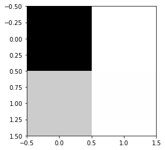

```
Accuracy 0.805
Confusion matrix
 [[1559   42]
 [ 348   51]]
```

```python
import matplotlib.pyplot as plt
conf = mt.confusion_matrix(y_test,y_hat)
plt.imshow(conf, cmap='binary', interpolation='None')
plt.show()
print("Accuracy", acc )
print("Confusion matrix\n",conf)
```

```python
# and here is an even shorter way of getting the accuracies for each training and test set
from sklearn.model_selection import cross_val_score
accuracies = cross_val_score(lr_clf, X, y=y, cv=cv_object) # this also can help with parallelism
print(accuracies)
```

```
[ 0.817   0.8135  0.8175]
```

```python
# here we can change some of the parameters interactively
from ipywidgets import widgets as wd

def lr_explor(cost):
    lr_clf = LogisticRegression(penalty='l2', C=cost, class_weight=None) # get object
    accuracies = cross_val_score(lr_clf,X,y=y,cv=cv_object) # this also can help with parallelism
    print(accuracies)

wd.interact(lr_explor,cost=(0.001,5.0,0.05),__manual=True)
```

```
<function __main__.lr_explor>
```

Running lr_explor doesn't display a significant gain when adjusting the 'C' value or the inverse of regulation strength. Double check the accuracy of the training set using a different method to validate

```python
from sklearn.linear_model import LogisticRegression
# instantiate a logistic regression model, and fit with X and y
model = LogisticRegression()
model = model.fit(X_train, y_train)

# check the accuracy on the training set
model.score(X_train, y_train)
```

```
0.81274999999999997
```

```python
y_train.mean()
```

```
0.19850000000000001
```

Weight interpretation Okay, so now lets take the last trained model for logistic regression and try to interpret the weights for the model. Is there something about the weights that makes this model more interpretable?

```python
# display the intercept
print ('Intercept value: ',lr_clf.intercept_)
# iterate over the coefficients
weights = lr_clf.coef_.T # take transpose to make a column vector
variable_names = df_imputed.columns
for coef, name in zip(weights,variable_names):
    print(name, 'has weight of', coef[0])
```

```
Intercept value:  [  4.90520244e-05]
CS has weight of -0.0125332871958
MIP has weight of 0.00116985644569
Units has weight of 9.80793325945e-05
OCLTV has weight of 0.00180007132147
DTI has weight of 0.0046645551565
OrigUPB has weight of -1.79002858468e-06
LTV has weight of 0.00186098852798
OrigInterestRate has weight of 0.000629559515445
OrigLoanTerm has weight of 0.017680160513
MonthsInRepayment has weight of 0.0123021043233
IsFirstTime has weight of -8.51772688532e-05
```

```python
# Weights of the Logistic Regression.
import numpy
numpy.std(df_imputed, axis=0)
```

```
CS                      50.915371
MIP                     13.281822
Units                    0.194384
OCLTV                   15.407798
DTI                     11.303776
OrigUPB              54122.681373
LTV                     15.400177
OrigInterestRate         0.351799
OrigLoanTerm             2.120882
MonthsInRepayment       45.227646
IsFirstTime              0.353206
dtype: float64
```

```python
from sklearn.preprocessing import StandardScaler

# scale attributes by the training set
scl_obj = StandardScaler()
scl_obj.fit(X_train) # find scalings for each column that make this zero mean and unit std
# the line of code above only looks at training data to get mean and std and we can use it
# to transform new feature data
X_train_scaled = scl_obj.transform(X_train) # apply to training
X_test_scaled = scl_obj.transform(X_test) # apply to test
# train the model
lr_clf = LogisticRegression(penalty='l2', C=0.05) # get object, the 'C' value is less (can you guess why??)
lr_clf.fit(X_train_scaled,y_train)  # train object

y_hat = lr_clf.predict(X_test_scaled) # get test set precitions

acc = mt.accuracy_score(y_test,y_hat)
conf = mt.confusion_matrix(y_test,y_hat)
print('accuracy:', acc )
print(conf )

# sort these attributes and spit them out
zip_vars = zip(lr_clf.coef_.T,df_imputed.columns) # combine attributes
zip_vars = sorted(zip_vars)
for coef, name in zip_vars:
    print(name, 'has weight of', coef[0]) # now print them out
```

```
accuracy: 0.8045
[[1555   46]
 [ 345   54]]
CS has weight of -0.603516842146
OrigUPB has weight of -0.0688297547771
IsFirstTime has weight of -0.0363373880374
OCLTV has weight of -0.0175874523328
LTV has weight of 0.012899844098
OrigLoanTerm has weight of 0.027588264941
Units has weight of 0.029902511432
DTI has weight of 0.062205663065
MIP has weight of 0.0637404832485
OrigInterestRate has weight of 0.130122893215
MonthsInRepayment has weight of 0.562181407646
```

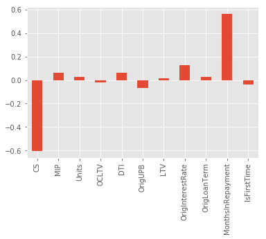

```python
# now let's make a pandas Series with the names and values, and plot them
from matplotlib import pyplot as plt
%matplotlib inline
plt.style.use('ggplot')

weights = pd.Series(lr_clf.coef_[0],index=df_imputed.columns)
weights.plot(kind='bar')
plt.show()
```

The above chart shows the different Logistic Regression weights that have been calculated. We can see that the CS (CreditScore) and MonthsInRepayment are the two largest contributors to classifying our response EverDelinquent. CS has a negative relationship while MonthsInRepayment has a positive relationship with being delinquent. What this means is that as CS increases, with all others held constant, the likelihood of a delinquency drops. Whereas, with all others held constant, as MonthsInRepayment increases, the likelihood of a delinquency on the loan increases.

```python
from sklearn.preprocessing import StandardScaler
# we want to normalize the features based upon the mean and standard deviation of each column.
# However, we do not want to accidentally use the testing data to find out the mean and std (this would be snooping)

from sklearn.pipeline import Pipeline
# you can apply the StandardScaler function inside of the cross-validation loop
#  but this requires the use of PipeLines in scikit.
#  A pipeline can apply feature pre-processing and data fitting in one compact notation
#  Here is an example!

std_scl = StandardScaler()
lr_clf = LogisticRegression(penalty='l2', C=0.05)

# create the pipline
piped_object = Pipeline([('scale', std_scl),  # do this
                         ('logit_model', lr_clf)]) # and then do this

weights = []
# run the pipline cross validated
for iter_num, (train_indices, test_indices) in enumerate(cv_object.split(X,y)):
    piped_object.fit(X[train_indices],y[train_indices])  # train object
    # it is a little odd getting trained objects from a  pipeline:
    weights.append(piped_object.named_steps['logit_model'].coef_[0])


weights = np.array(weights)
```

```python
import plotly
plotly.offline.init_notebook_mode() # run at the start of every notebook

error_y=dict(
            type='data',
            array=np.std(weights,axis=0),
            visible=True
        )

graph1 = {'x': df_imputed.columns,
          'y': np.mean(weights,axis=0),
    'error_y':error_y,
       'type': 'bar'}

fig = dict()
fig['data'] = [graph1]
fig['layout'] = {'title': 'Logistic Regression Weights, with error bars'}

plotly.offline.iplot(fig)
```

[output not shown]

[interactive chart not shown]

```python
# Removing MonthsDelinquent and running below
Xnew = df_imputed[['CS','MIP','Units','OCLTV', 'DTI','OrigUPB','LTV','OrigInterestRate','OrigLoanTerm','MonthsInRepayment','IsFirstTime']].values

weights = []
# run the pipline corssvalidated
for iter_num, (train_indices, test_indices) in enumerate(cv_object.split(Xnew,y)):
    piped_object.fit(Xnew[train_indices],y[train_indices])  # train object
    weights.append(piped_object.named_steps['logit_model'].coef_[0])

weights = np.array(weights)

error_y=dict(
            type='data',
            array=np.std(weights,axis=0),
            visible=True
        )

graph1 = {'x': ['CS','MIP','Units','OCLTV', 'DTI','OrigUPB','LTV','OrigInterestRate','OrigLoanTerm','MonthsInRepayment','IsFirstTime'],
          'y': np.mean(weights,axis=0),
    'error_y':error_y,
       'type': 'bar'}

fig = dict()
fig['data'] = [graph1]
fig['layout'] = {'title': 'Logistic Regression Weights, with error bars'}

plotly.offline.iplot(fig)
```

[interactive chart not shown]

Back to Index

# Modeling and Evaluation 3 - SVM - EverDelinquent

```
In this section we will create our SVM model. Once created, we will explore how changing the parameters for each model affects the model by our chosen metrics of Accuracy and Precision.
```

```
[0 0 0 ..., 0 0 0]
```

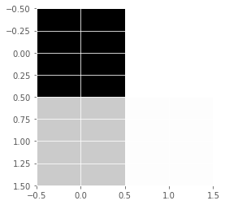

```
accuracy: 0.807
[[1566   35]
 [ 351   48]]
```

```python
# lets investigate SVMs on the data and play with the parameters and kernels
from sklearn import svm

# train the model just as before
#svm_clf = svm.SVC(C=0.5, kernel='rbf', degree=3, gamma='auto')
# SVC with Kernel rbf or linear is taking for ever to run, hence switching to LinearSVC

svm_clf = svm.LinearSVC(C=0.5) # get object
svm_clf.fit(X_train_scaled, y_train)  # train object

y_hat = svm_clf.predict(X_test_scaled) # get test set precitions

print(y_hat)
acc = mt.accuracy_score(y_test,y_hat)
conf = mt.confusion_matrix(y_test,y_hat)
plt.imshow(conf, cmap='binary', interpolation='None')
plt.show()
print('accuracy:', acc )
print(conf)
```

### SVM

In this SVM model, we are trying to create a high accuracy model capable of classifying a record whose details of CS,MIP,Units,OCLTV,DTI,OrigUPB,LTV,OrigInterestRate,OrigLoanTerm,MonthsInRepaymentIsFirstTime we know, into either delinquent [Everdelinquent = 1] or not delinquent [Everdelinquent =0 ], this is a very useful model that can be used by banks at the time of refinancing a loan or giving a new loan for the same borrower, the details of CS,MIP,Units,OCLTV,DTI,OrigUPB,LTV,OrigInterestRate,OrigLoanTerm,MonthsInRepaymentIsFirstTime for the borrower could change reguarly, so the model, if satisfactory, needs to be deployed in such a way that the it refreshes every day and the latest model needs to be used to classify/predict whether a borrower could lead to a delinquent loan.

The SVM model Accuracy = 80.7% and the Precision = (1566/(1566+351)) = 81.7%

```
[0 0 0 ..., 0 0 0]
```

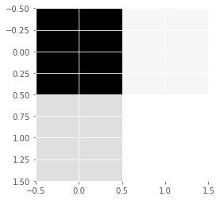

```
accuracy: 0.7755
[[1435  166]
 [ 283  116]]
```

```python
# Stochastic Gradient Descent
from sklearn.linear_model import SGDClassifier
clf = SGDClassifier(loss="hinge", penalty="l2")
clf.fit(X_train_scaled, y_train)  # train object
SGDClassifier(alpha=0.0001, average=False, class_weight=None, epsilon=0.1,
       eta0=0.0, fit_intercept=True, l1_ratio=0.15,
       learning_rate='optimal', loss='hinge', n_iter=5, n_jobs=1,
       penalty='l2', power_t=0.5, random_state=None, shuffle=True,
       verbose=0, warm_start=False)
y_hat = clf.predict(X_test_scaled) # get test set precitions
print(y_hat)
acc = mt.accuracy_score(y_test,y_hat)
conf = mt.confusion_matrix(y_test,y_hat)
plt.imshow(conf, cmap='binary', interpolation='None')
plt.show()
print('accuracy:', acc )
print(conf)
```

### Stochastic Gradient Descent

The above Accuracy = 77.6% and the Precision = (1435/(1435+283)) = 83.5%

Back to Index

# Modeling and Evaluation 4 - SVM - EverDelinquent

```
In this section we analyze our obtained results from the previous section using our chosen evaluation metrics of
Accuracy and Precision.  Also, we will provide and explain visualizations that help in understanding why our
model is or is not useful for our dataset.
```

For SVM we will analyze Accuracy and Precision. The visualizations of the Confusion Matrix and Support Vectors will be analyzed to provide insight into the model, its interpretation, and usefulness.

The different models that we have used had the following accuracies for each run truncated to three decimal places.

```
Support Vector Machines: Accuracy = 80.7%, Precision = 81.7%
Stochastic Gradient Descent: Accuracy = 77.6%, Precision = 83.5%
```

As can be seen the Accuracy and Precision of both the SVM and Stochastic Gradient Descent models, the SVM model is a better classifier of the EverDelinquent response. SVM is better because it has a higher accuracy, meaning it has classified more correctly while it's precision is marginally lower than Stochastic Gradient Descent. Both models ran quickly and there was no appreciable difference in performance. We will not move onto further analysis of our SVM models by looking at the chosen Support Vectors.

## Chosen Support Vectors for Classification Task

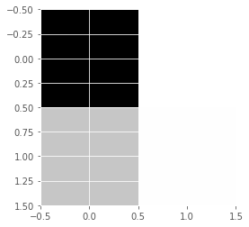

```
accuracy: 0.8065
[[1585   16]
 [ 371   28]]
```

```python
# lets investigate SVMs on the data and play with the parameters and kernels
from sklearn.svm import SVC

# train the model just as before
svm_clf = SVC(C=0.5, kernel='rbf', degree=3, gamma='auto') # get object
svm_clf.fit(X_train_scaled, y_train)  # train object

y_hat = svm_clf.predict(X_test_scaled) # get test set precitions

acc = mt.accuracy_score(y_test,y_hat)
conf = mt.confusion_matrix(y_test,y_hat)
plt.imshow(conf, cmap='binary', interpolation='None')
plt.show()
print('accuracy:', acc )
print(conf)
```

```python
# look at the support vectors
print(svm_clf.support_vectors_.shape)
print(svm_clf.support_.shape)
print(svm_clf.n_support_ )
```

```
(3439, 11)
(3439,)
[1877 1562]
```

```python
# Now let's do some different analysis with the SVM and look at the instances that were chosen as support vectors
# make a dataframe of the training data
df_tested_on = df_imputed.iloc[train_indices] # saved from above, the indices chosen for training
# now get the support vectors from the trained model
df_support = df_tested_on.iloc[svm_clf.support_,:]

df_support['EverDelinquent'] = y[svm_clf.support_]
df_imputed['EverDelinquent'] = y # also add it back in for the original data
df_support.info()
```

```
<class 'pandas.core.frame.DataFrame'>
Int64Index: 3439 entries, 193462 to 232031
Data columns (total 12 columns):
CS                   3439 non-null int64
MIP                  3439 non-null int64
Units                3439 non-null int64
OCLTV                3439 non-null int64
DTI                  3439 non-null int64
OrigUPB              3439 non-null int64
LTV                  3439 non-null int64
OrigInterestRate     3439 non-null float64
OrigLoanTerm         3439 non-null int64
MonthsInRepayment    3439 non-null int64
IsFirstTime          3439 non-null int32
EverDelinquent       3439 non-null int64
dtypes: float64(1), int32(1), int64(10)
memory usage: 335.8 KB
```

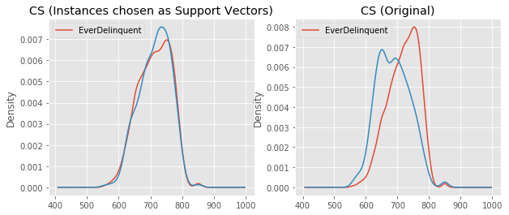

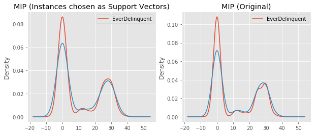

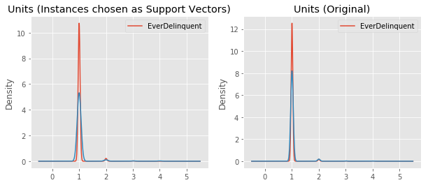

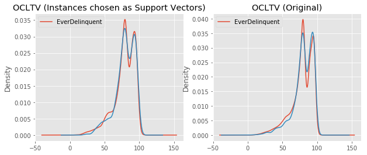

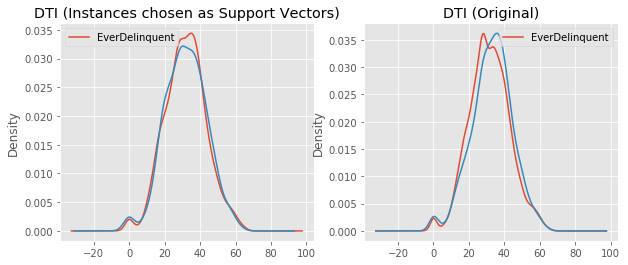

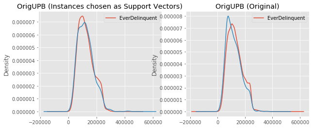

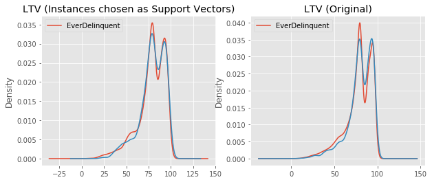

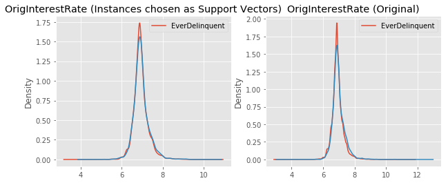

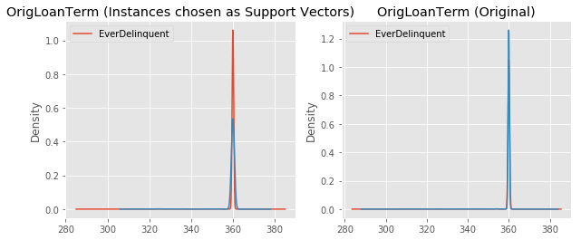

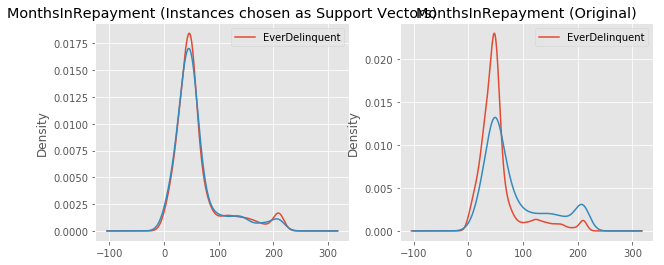

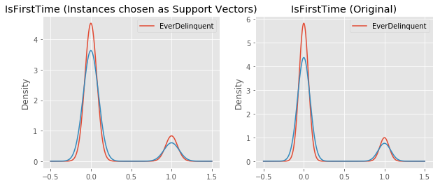

```python
# now lets see the statistics of these attributes
from pandas.tools.plotting import boxplot

# group the original data and the support vectors
df_grouped_support = df_support.groupby(['EverDelinquent'])
df_grouped = df_imputed.groupby(['EverDelinquent'])

# plot KDE of Different variables
vars_to_plot = ['CS','MIP','Units', 'OCLTV', 'DTI', 'OrigUPB', 'LTV', 'OrigInterestRate',  'OrigLoanTerm', 'MonthsInRepayment', 'IsFirstTime']


for v in vars_to_plot:
    plt.figure(figsize=(10,4))
    # plot support vector stats
    plt.subplot(1,2,1)
    ax = df_grouped_support[v].plot.kde()
    plt.legend(['EverDelinquent'])
    plt.title(v+' (Instances chosen as Support Vectors)')

    # plot original distributions
    plt.subplot(1,2,2)
    ax = df_grouped[v].plot.kde()
    plt.legend(['EverDelinquent'])
    plt.title(v+' (Original)')
```

The discrepancy between the support vector and original are more present possibly because the support vector is tuning into the edge cases that exist in the data and or because of classification errors in the training set.

Back to Index  
Back to Exceptional Work

# Modeling and Evaluation 3 - KNN - EverDelinquent

In this KNN classification model, we are trying to create a high accuracy model capable of classifying a record whose details of CS,MIP,Units,OCLTV,DTI,OrigUPB,LTV,OrigInterestRate,OrigLoanTerm,MonthsInRepaymentIsFirstTime we know, into either delinquent [Everdelinquent = 1] or not delinquent [Everdelinquent =0 ], this is a very useful model that can be used by banks at the time of refinancing a loan or giving a new loan for the same borrower, the details of CS,MIP,Units,OCLTV,DTI,OrigUPB,LTV,OrigInterestRate,OrigLoanTerm,MonthsInRepaymentIsFirstTime for the borrower could change reguarly, so the model, if satisfactory, needs to be deployed in such a way that the it refreshes every day and the latest model needs to be used to classify/predict whether a borrower could lead to a delinquent loan.

Let's start with a simple classifier and ten fold cross validation, calculating accuracy to start.

```python
from sklearn.model_selection import ShuffleSplit

# we want to predict the X and y data as follows:
if 'EverDelinquent' in df_imputed:
    y = df_imputed['EverDelinquent'].values # get the labels we want
    del df_imputed['EverDelinquent'] # get rid of the class label
    X = df_imputed.values # use everything else to predict!

    ## X and y are now numpy matrices, by calling 'values' on the pandas data frames we
    #    have converted them into simple matrices to use with scikit learn
```

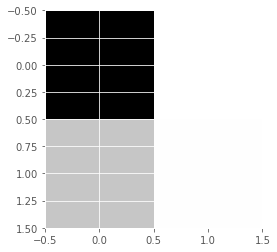

```
KNNaccuracy: 0.7715
[[1585   16]
 [ 371   28]]
Wall time: 2.47 s
```

```python
%%time
from sklearn.neighbors import KNeighborsClassifier
from sklearn.model_selection import StratifiedKFold
from sklearn.preprocessing import StandardScaler
import numpy as np
from sklearn import metrics as mt
yhat = np.zeros(y.shape) # we will fill this with predictions
scl = StandardScaler()
X = scl.fit_transform(X)
# create cross validation iterator
cv = StratifiedKFold(n_splits=10)
# get a handle to the classifier object, which defines the type
clf = KNeighborsClassifier(n_neighbors=3)
# now iterate through and get predictions, saved to the correct row in yhat
# NOTE: you can parallelize this using the cross_val_predict method
for train, test in cv.split(X,y):
    clf.fit(X[train],y[train])
    yhat[test] = clf.predict(X[test])

total_accuracy = mt.accuracy_score(y, yhat)
plt.imshow(conf, cmap='binary', interpolation='None')
plt.show()
print('KNNaccuracy:', total_accuracy )
print(conf)
```

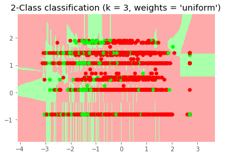

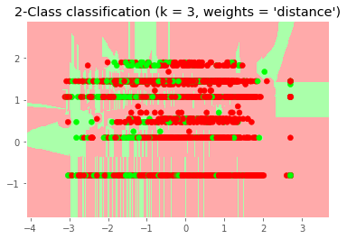

```python
import numpy as np
import matplotlib.pyplot as plt
from matplotlib.colors import ListedColormap
from sklearn import neighbors, datasets

n_neighbors = 3
h = .02  # step size in the mesh
Newx = X[:, :2]
# Create color maps
cmap_light = ListedColormap(['#FFAAAA', '#AAFFAA'])
cmap_bold = ListedColormap(['#FF0000', '#00FF00'])

for weights in ['uniform', 'distance']:
    # we create an instance of Neighbours Classifier and fit the data.
    clf = neighbors.KNeighborsClassifier(n_neighbors, weights=weights)
    clf.fit(Newx, y)

    # Plot the decision boundary. For that, we will assign a color to each
    # point in the mesh [x_min, x_max]x[y_min, y_max].
    x_min, x_max = X[:, 0].min() - 1, X[:, 0].max() + 1
    y_min, y_max = X[:, 1].min() - 1, X[:, 1].max() + 1
    xx, yy = np.meshgrid(np.arange(x_min, x_max, h),
                         np.arange(y_min, y_max, h))
    Z = clf.predict(np.c_[xx.ravel(), yy.ravel()])

    # Put the result into a color plot
    Z = Z.reshape(xx.shape)
    plt.figure()
    plt.pcolormesh(xx, yy, Z, cmap=cmap_light)

    # Plot also the training points
    plt.scatter(X[:, 0], X[:, 1], c=y, cmap=cmap_bold)
    plt.xlim(xx.min(), xx.max())
    plt.ylim(yy.min(), yy.max())
    plt.title("2-Class classification (k = %i, weights = '%s')"
              % (n_neighbors, weights))

plt.show()
```

The above graphs are showing us the normalized data that is being trained on along with the exact KNN boundaries being drawn between the two calsses. For a perfect classification all of the Red points should be in the Red highlighted regions and all of the Green points in the Green highlighted regions. As expected with a 77% accuracy, we see quite a few points in the incorrect region.

Back to Index  
Back to Exceptional Work

# Modeling and Evaluation 4 - KNN - EverDelinquent

```
In this section we analyze our obtained results from the previous section using our chosen evaluation metrics of
Accuracy and Precision.  Also, we will provide and explain visualizations that help in understanding why our
model is or is not useful for our dataset.
```

For our KNN model we will analyze Accuracy and Precision. The visualizations of In-Class Accuracies and the Confusion Matrix will be analyzed to provide insight into the model, its interpretation, and usefulness.

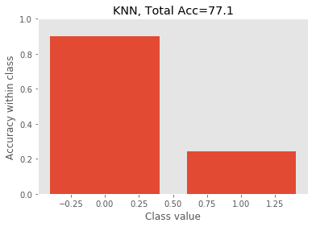

```python
from matplotlib import pyplot as plt
import numpy as np
%matplotlib inline

def per_class_accuracy(ytrue,yhat):
    conf = mt.confusion_matrix(ytrue,yhat)
    norm_conf = conf.astype('float') / conf.sum(axis=1)[:, np.newaxis]
    return np.diag(norm_conf)

def plot_class_acc(ytrue,yhat, title=''):
    acc_list = per_class_accuracy(ytrue,yhat)
    plt.bar(range(len(acc_list)), acc_list)
    plt.xlabel('Class value')
    plt.ylabel('Accuracy within class')
    plt.title(title+", Total Acc=%.1f"%(100*mt.accuracy_score(ytrue,yhat)))
    plt.grid()
    plt.ylim([0,1])
    plt.show()

plot_class_acc(y,yhat,title="KNN")
```

The above graph breaks down the class values, in our case 0 and 1 for EverDelinquent, along with their respective accuracy. We can see that KNN had an accuracy of approximately 90% in classifying loans that had never been delinquent. Also, KNN had an accuracy of approximately 25% in classifying loans that had been delinquent.

Unfortunately, this is not very useful for us as we don't as much care whether we can classify loans that had never been delinquent. Our main goal is to accurately classify the delinquent loans. This graph shows that while KNN has a fair total accuracy of 77.1%, it is not a good model for our data.

Back to Index

# Modeling and Evaluation 3 - Random Forest - EverDelinquent

```
In this section we will create our Random Forest model. Once created, we will explore how changing the
parameters for each model affects the model by our chosen metrics of Accuracy and Precision.
```

In this Random forest model, we are trying to create a high accuracy model capable of classifying a record whose details of CS,MIP,Units,OCLTV,DTI,OrigUPB,LTV,OrigInterestRate,OrigLoanTerm,MonthsInRepaymentIsFirstTime we know, into either delinquent [Everdelinquent = 1] or not delinquent [Everdelinquent =0 ], this is a very useful model that can be used by banks at the time of refinancing a loan or giving a new loan for the same borrower, the details of CS,MIP,Units,OCLTV,DTI,OrigUPB,LTV,OrigInterestRate,OrigLoanTerm,MonthsInRepaymentIsFirstTime for the borrower could change reguarly, so the model, if satisfactory, needs to be deployed in such a way that the it refreshes every day and the latest model needs to be used to classify/predict whether a borrower could lead to a delinquent loan.

```python
%%time
from sklearn.decomposition import PCA
from sklearn.pipeline import Pipeline
from sklearn.ensemble import RandomForestClassifier
from sklearn import metrics as mt
from sklearn.neighbors import KNeighborsClassifier
from sklearn.model_selection import StratifiedKFold
from sklearn.preprocessing import StandardScaler

#RandomForest+PCA

yhat = np.zeros(y.shape) # we will fill this with predictions

scl = StandardScaler()
X = scl.fit_transform(X)

# create cross validation iterator
cv = StratifiedKFold(n_splits=10)

clf_pipe = Pipeline(
    [('PCA',PCA(n_components=11, svd_solver='randomized')),
     ('CLF',RandomForestClassifier(max_depth=50, n_estimators=150, n_jobs=-1))]
)

# now iterate through and get predictions, saved to the correct row in yhat
for train, test in cv.split(X,y):
    clf_pipe.fit(X[train],y[train])
    yhat[test] = clf_pipe.predict(X[test])

conf = mt.confusion_matrix(y,yhat)
total_accuracy = mt.accuracy_score(y, yhat)
print ('Pipeline accuracy', total_accuracy)
print(conf)
```

```
Pipeline accuracy 0.8026
[[7695  318]
 [1656  331]]
Wall time: 13.5 s
```

For the Random Forest model we receive an Accuracy = 80% and a Precision = (7695/(7695+1656)) = 82.3%. It takes this model 13.5 seconds to complete. While this appears to be a good model we need to investigate the in-class accuracies to see if this also suffers from the same weakness as KNN.

Back to Index

# Modeling and Evaluation 4 - Random Forest - EverDelinquent

```
In this section we analyze our obtained results from the previous section using our chosen evaluation metrics of
Accuracy and Precision.  Also, we will provide and explain visualizations that help in understanding why our
model is or is not useful for our dataset.
```

For our Random Forest model we will analyze Accuracy and Precision. The visualizations of In-Class Accuracy and the Confusion Matrix will be analyzed to provide insight into the model, its interpretation, and usefulness.

```
Accuracy 0.8046
```

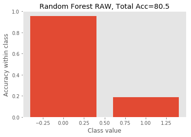

```
Wall time: 9.09 s
```

```python
%%time
from sklearn.ensemble import RandomForestClassifier
#raw random forest
clf = RandomForestClassifier(max_depth=50, n_estimators=150, n_jobs=-1, oob_score=True)

# now iterate through and get predictions, saved to the correct row in yhat
for train, test in cv.split(X,y):
    clf.fit(X[train],y[train])
    yhat[test] = clf.predict(X[test])

total_accuracy = mt.accuracy_score(y, yhat)
print ('Accuracy', total_accuracy)
plot_class_acc(y,yhat,title="Random Forest RAW")
```

We can see that Random Forest produces a decent total Accuracy = 80.5% in classifying the EverDelinquent class. Unfortunately, upon deeper investigation we see that the In-Class categorization of a loan having been delinquent is actually very low at just less than 20%. The Random Forest model suffers from the same issue as KNN in that it classifies our never delinquent loans very accurately while not classifying the delinquent loans accurately.

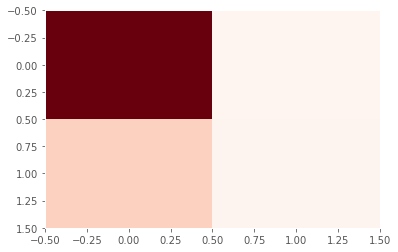

```python
from sklearn import metrics as mt
# how about plotting a confusion matrix?
cm = mt.confusion_matrix(y, yhat)
plt.imshow(cm,cmap=plt.get_cmap('Reds'),aspect='auto')
plt.grid(False)
```

Back to Index

# Modeling and Evaluation 3 - Naive Bayes - EverDelinquent

```
In this section we will create our Naive Bayes model. Once created, we will explore how changing the parameters for each model affects the model by our chosen metrics of Accuracy and Precision.
```

```python
#NaiveBayes+PCA

# from sklearn.svm import SVC
# from sklearn.linear_model import LogisticRegression
# from sklearn.linear_model import SGDClassifier
from sklearn.naive_bayes import GaussianNB

# setup pipeline to take PCA, then fit a different classifier
clf_pipe = Pipeline(
    [('PCA',PCA(n_components=11,svd_solver='randomized')),
     ('CLF',GaussianNB())]
)

# now iterate through and get predictions, saved to the correct row in yhat
for train, test in cv.split(X,y):
    clf_pipe.fit(X[train],y[train])
    yhat[test] = clf_pipe.predict(X[test])

total_accuracy = mt.accuracy_score(y, yhat)
print ('Pipeline accuracy', total_accuracy)
```

```
Pipeline accuracy 0.7409
```

Back to Index

# Modeling and Evaluation 4 - Naive Bayes - EverDelinquent

```
In this section we analyze our obtained results from the previous section using our chosen evaluation metrics of
Accuracy and Precision.  Also, we will provide and explain visualizations that help in understanding why our
model is or is not useful for our dataset.
```

For our Naive Bayes model we will analyze Accuracy and Precision. The visualizations of the Confusion Matrix and In-Class Accuracy will be analyzed to provide insight into the model, its interpretation, and usefulness.

In this Naive Bayes model, we are trying to create a high accuracy model capable of classifying a record whose details of CS,MIP,Units,OCLTV,DTI,OrigUPB,LTV,OrigInterestRate,OrigLoanTerm,MonthsInRepaymentIsFirstTime we know, into either delinquent [Everdelinquent = 1] or not delinquent [Everdelinquent =0 ], this is a very useful model that can be used by banks at the time of refinancing a loan or giving a new loan for the same borrower, the details of CS,MIP,Units,OCLTV,DTI,OrigUPB,LTV,OrigInterestRate,OrigLoanTerm,MonthsInRepaymentIsFirstTime for the borrower could change reguarly, so the model, if satisfactory, needs to be deployed in such a way that the it refreshes every day and the latest model needs to be used to classify/predict whether a borrower could lead to a delinquent loan.

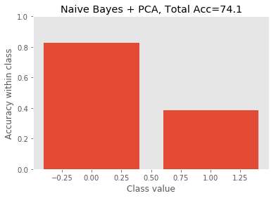

```python
plot_class_acc(y,yhat,title="Naive Bayes + PCA")
```

```
[[6642 1371]
 [1220  767]]
```

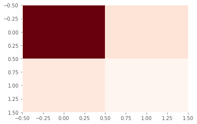

```python
from sklearn import metrics as mt
# how about plotting a confusion matrix?
cm = mt.confusion_matrix(y, yhat)
plt.imshow(cm,cmap=plt.get_cmap('Reds'),aspect='auto')
plt.grid(False)
print(cm)
```

```
Range of: -0.0278825330883 0.153405042211
0.740942427442 0.803703682004
```

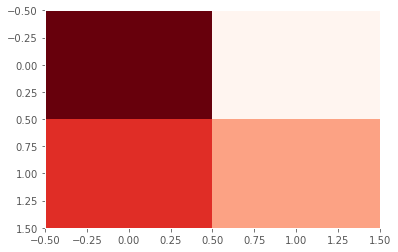

```python
clf1 = Pipeline(
    [('PCA',PCA(n_components=11,svd_solver='randomized')),
     ('CLF',GaussianNB())]
)

clf2 = Pipeline(
    [('PCA',PCA(n_components=11, svd_solver='randomized')),
     ('CLF',RandomForestClassifier(max_depth=50, n_estimators=150, n_jobs=-1))]
)



from sklearn.model_selection import cross_val_score
# is clf1 better or worse than clf2?
cv=StratifiedKFold(n_splits=10)
acc1 = cross_val_score(clf1, X, y=y, cv=cv)
acc2 = cross_val_score(clf2, X, y=y, cv=cv)

#=================================

t = 2.26 / np.sqrt(10)

e = (1-acc1)-(1-acc2)
# std1 = np.std(acc1)
# std2 = np.std(acc2)
stdtot = np.std(e)

dbar = np.mean(e)
print ('Range of:', dbar-t*stdtot,dbar+t*stdtot )
print (np.mean(acc1), np.mean(acc2))


#===============================
cm_normalized = cm.astype('float') / cm.sum(axis=1)[:, np.newaxis]
plt.imshow(cm_normalized,cmap=plt.get_cmap('Reds'),aspect='auto')
plt.grid(False)
```

Back to Index  
Back to Exceptional Work

# Modeling and Evaluation 3 - Logistic Regression - CreditRange

```
In this section we will create our Logistic Regression model. Once created, we will explore how changing the
parameters for each model affects the model by our chosen metrics of Accuracy and Precision
```

New Classification task: Classify into what credit range the borrower had given all other details of an inforce / delinquent loan

In this classification task, we are trying to predict the possible credit range of the borrower at the time the loan was given. We will try to classify a borrowers in force loan record into one out of the below 4 classes: Poor (0-650), Fair (650-700), Good (700-750), Excellent (750-900)

The reason you might need a model like this is to use loans in force, in production to independently calculate the credit worthiness of the borrower at the time the loan was given, it is useful in independent audits.

```python
df_imputed_cs.info()
y = df_imputed_cs['MonthsDelinquent'].values
```

```
<class 'pandas.core.frame.DataFrame'>
Int64Index: 10000 entries, 9315 to 54578
Data columns (total 14 columns):
CS                   10000 non-null int64
MIP                  10000 non-null int64
Units                10000 non-null int64
OCLTV                10000 non-null int64
DTI                  10000 non-null int64
OrigUPB              10000 non-null int64
LTV                  10000 non-null int64
OrigInterestRate     10000 non-null float64
OrigLoanTerm         10000 non-null int64
EverDelinquent       10000 non-null int64
MonthsDelinquent     10000 non-null int64
MonthsInRepayment    10000 non-null int64
IsFirstTime          10000 non-null int32
CreditRange          10000 non-null category
dtypes: category(1), float64(1), int32(1), int64(11)
memory usage: 1.0 MB
```

```python
from sklearn.model_selection import ShuffleSplit
from statsmodels.tools import categorical

df_imputed_cs.head()
df_imputed_cs.info()

# we want to predict the X and y data as follows:

y = df_imputed_cs['CreditRange'].values # get the labels we want
print (y)
del df_imputed_cs['CreditRange'] # get rid of the class label
del df_imputed_cs['CS'] # get rid of the class label
X = df_imputed_cs.values # use everything else to predict!



    ## X and y are now numpy matrices, by calling 'values' on the pandas data frames we
    #    have converted them into simple matrices to use with scikit learn


# to use the cross validation object in scikit learn, we need to grab an instance
#    of the object and set it up. This object will be able to split our data into
#    training and testing splits
num_cv_iterations = 3
num_instances = len(y)
cv_object = ShuffleSplit(n_splits=num_cv_iterations,
                         test_size  = 0.2)

print(cv_object)
```

```
<class 'pandas.core.frame.DataFrame'>
Int64Index: 10000 entries, 9315 to 54578
Data columns (total 14 columns):
CS                   10000 non-null int64
MIP                  10000 non-null int64
Units                10000 non-null int64
OCLTV                10000 non-null int64
DTI                  10000 non-null int64
OrigUPB              10000 non-null int64
LTV                  10000 non-null int64
OrigInterestRate     10000 non-null float64
OrigLoanTerm         10000 non-null int64
EverDelinquent       10000 non-null int64
MonthsDelinquent     10000 non-null int64
MonthsInRepayment    10000 non-null int64
IsFirstTime          10000 non-null int32
CreditRange          10000 non-null category
dtypes: category(1), float64(1), int32(1), int64(11)
memory usage: 1.0 MB
[1, 3, 3, 2, 1, ..., 4, 1, 4, 3, 2]
Length: 10000
Categories (4, int64): [1 < 2 < 3 < 4]
ShuffleSplit(n_splits=3, random_state=None, test_size=0.2, train_size=None)
```

In this Logistic regression model, we are trying to predict the possible credit range of the borrower at the time the loan was given. We will try to classify a borrowers in force loan record into one out of the below 4 classes: Poor (0-650), Fair (650-700), Good (700-750), Excellent (750-900)

```python
# run logistic regression and vary some parameters
from sklearn.linear_model import LogisticRegression
from sklearn import metrics as mt

# first we create a reusable logisitic regression object
#   here we can setup the object with different learning parameters and constants
lr_clf = LogisticRegression(penalty='l2', C=1.0, class_weight=None) # get object

# now we can use the cv_object that we setup before to iterate through the
#    different training and testing sets. Each time we will reuse the logisitic regression
#    object, but it gets trained on different data each time we use it.

iter_num=0
# the indices are the rows used for training and testing in each iteration
for train_indices, test_indices in cv_object.split(X,y):
    # I will create new variables here so that it is more obvious what
    # the code is doing (you can compact this syntax and avoid duplicating memory,
    # but it makes this code less readable)
    X_train = X[train_indices]
    y_train = y[train_indices]

    X_test = X[test_indices]
    y_test = y[test_indices]

    # train the reusable logisitc regression model on the training data
    lr_clf.fit(X_train,y_train)  # train object
    y_hat = lr_clf.predict(X_test) # get test set precitions
    print(y_hat)

    # now let's get the accuracy and confusion matrix for this iterations of training/testing
    acc = mt.accuracy_score(y_test,y_hat)
    conf = mt.confusion_matrix(y_test,y_hat)
    print("==== Iteration",iter_num," ====")
    print("Accuracy", acc )
    print("Confusion matrix\n",conf)
    iter_num+=1

# Also note that every time you run the above code
#   it randomly creates a new training and testing set,
#   so accuracy will be different each time
```

```
[4 3 3 ..., 3 4 4]
==== Iteration 0  ====
Accuracy 0.369
Confusion matrix
 [[  8  27 188  34]
 [  5  45 385  82]
 [  4  44 483 162]
 [  1  13 317 202]]
[4 3 3 ..., 2 3 3]
==== Iteration 1  ====
Accuracy 0.381
Confusion matrix
 [[  9  49 162  39]
 [  7  71 327  94]
 [  7  90 439 183]
 [  0  36 244 243]]
[3 3 3 ..., 3 3 3]
==== Iteration 2  ====
Accuracy 0.36
Confusion matrix
 [[  9  10 217  23]
 [  6  22 423  92]
 [  2  24 497 147]
 [  0  11 325 192]]
```

Back to Index  
Back to Exceptional Work

# Modeling and Evaluation 4 - Logistic Regression - CreditRange

```
In this section we analyze our obtained results from the previous section using our chosen evaluation metrics of
Accuracy.  Also, we will provide and explain visualizations that help in understanding why our
model is or is not useful for our dataset.
```

For Logistic Regression we will analyze Accuracy of the model. The visualizations of the Confusion Matrix and the Logistic Regression Weights will be analyzed to provide insight into the model, its interpretation, and usefulness.

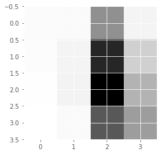

```
Accuracy 0.36
Confusion matrix
 [[  9  10 217  23]
 [  6  22 423  92]
 [  2  24 497 147]
 [  0  11 325 192]]
```

```python
import matplotlib.pyplot as plt
conf = mt.confusion_matrix(y_test,y_hat)
plt.imshow(conf, cmap='binary', interpolation='None')
plt.show()
print("Accuracy", acc )
print("Confusion matrix\n",conf)
```

The model is not doing a great job of predicting the right class, as can be seen from the above confusion matrix. The total accuracy of the model = 36%.

```python
from sklearn.linear_model import LogisticRegression
# instantiate a logistic regression model, and fit with X and y
model = LogisticRegression()
model = model.fit(X_train, y_train)
```

```python
# check the accuracy on the training set
model.score(X_train, y_train)
```

```
0.37325000000000003
```

```python
# display the intercept
print ('Intercept value: ',lr_clf.intercept_)
```

```
Intercept value:  [ -2.64488044e-05  -1.94054605e-05  -4.66559240e-06   1.36817201e-05]
```

```python
# iterate over the coefficients
weights = lr_clf.coef_.T # take transpose to make a column vector
variable_names = df_imputed_cs.columns
for coef, name in zip(weights,variable_names):
    print(name, 'has weight of', coef[0])
```

```
MIP has weight of 0.00478730031987
Units has weight of 3.48219281312e-05
OCLTV has weight of 0.0078355001125
DTI has weight of 0.0063332999086
OrigUPB has weight of -1.59700001956e-06
LTV has weight of 0.00783814318147
OrigInterestRate has weight of 0.000750208234361
OrigLoanTerm has weight of -0.00882569084771
EverDelinquent has weight of 0.00229283807474
MonthsDelinquent has weight of 0.0280216687258
MonthsInRepayment has weight of -0.00119103490227
IsFirstTime has weight of 6.20323553218e-05
```

```python
# When interpreting weights, it is important to view the standard deviation and range of values that are included in the sample.

import numpy
numpy.std(df_imputed_cs, axis=0)
```

```
MIP                     13.196405
Units                    0.185331
OCLTV                   15.298457
DTI                     11.374006
OrigUPB              53088.899781
LTV                     15.284636
OrigInterestRate         0.348108
OrigLoanTerm             2.256098
EverDelinquent           0.395119
MonthsDelinquent         8.877483
MonthsInRepayment       44.478987
IsFirstTime              0.345110
dtype: float64
```

```python
from sklearn.preprocessing import StandardScaler

# we want to normalize the features based upon the mean and standard deviation of each column.
# However, we do not want to accidentally use the testing data to find out the mean and std (this would be snooping)
# to Make things easier, let's start by just using whatever was last stored in the variables:
##    X_train , y_train , X_test, y_test (they were set in a for loop above)

# scale attributes by the training set
scl_obj = StandardScaler()
scl_obj.fit(X_train) # find scalings for each column that make this zero mean and unit std
# the line of code above only looks at training data to get mean and std and we can use it
# to transform new feature data

X_train_scaled = scl_obj.transform(X_train) # apply to training
X_test_scaled = scl_obj.transform(X_test) # apply those means and std to the test set (without snooping at the test set values)

# train the model just as before
lr_clf = LogisticRegression(penalty='l2', C=0.05) # get object, the 'C' value is less (can you guess why??)
lr_clf.fit(X_train_scaled,y_train)  # train object

y_hat = lr_clf.predict(X_test_scaled) # get test set precitions

acc = mt.accuracy_score(y_test,y_hat)
conf = mt.confusion_matrix(y_test,y_hat)
print('accuracy:', acc )
print(conf )

# sort these attributes and spit them out
weights = lr_clf.coef_.T # take transpose to make a column vector
variable_names = df_imputed_cs.columns
for coef, name in zip(weights,variable_names):
    print(name, 'has weight of', coef[0])
```

```
accuracy: 0.393
[[ 18  92 127  22]
 [ 16 137 307  83]
 [  5  85 412 168]
 [  2  34 273 219]]
MIP has weight of 0.0204398474312
Units has weight of 0.0137071103494
OCLTV has weight of 0.137120655843
DTI has weight of 0.0365944721123
OrigUPB has weight of -0.0305749895682
LTV has weight of 0.136110584555
OrigInterestRate has weight of 0.190364451054
OrigLoanTerm has weight of 0.00922259323571
EverDelinquent has weight of 0.42230222929
MonthsDelinquent has weight of 0.146629494882
MonthsInRepayment has weight of -0.107598642728
IsFirstTime has weight of 0.00347658810128
```

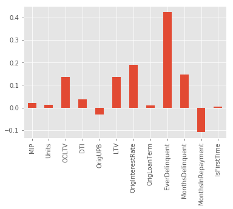

```python
# now let's make a pandas Series with the names and values, and plot them
from matplotlib import pyplot as plt
%matplotlib inline
plt.style.use('ggplot')


weights = pd.Series(lr_clf.coef_[0],index=df_imputed_cs.columns)
weights.plot(kind='bar')
plt.show()
```

Back to Index

# Modeling and Evaluation 3 - SVM - CreditRange

```
In this section we will create our SVM model. Once created, we will explore how changing the parameters for each model affects the model by our chosen metrics of Accuracy.
```

In this SVM model, we are trying to predict the possible credit range of the borrower at the time the loan was given. We will try to classify a borrowers in force loan record into one out of the below 4 classes: Poor (0-650), Fair (650-700), Good (700-750), Excellent (750-900), Once created, we will explore how changing the parameters for each model affects the model by our chosen metrics of Accuracy.

```python
# lets investigate SVMs on the data and play with the parameters and kernels
from sklearn import svm

# train the model just as before
#svm_clf = svm.SVC(C=0.5, kernel='rbf', degree=3, gamma='auto')
# SVC with Kernel rbf or linear is taking for ever to run, hence switching to LinearSVC

svm_clf = svm.LinearSVC(C=0.5) # get object
svm_clf.fit(X_train_scaled, y_train)  # train object

y_hat = svm_clf.predict(X_test_scaled) # get test set precitions

print(y_hat)
acc = mt.accuracy_score(y_test,y_hat)
conf = mt.confusion_matrix(y_test,y_hat)
print('accuracy:', acc )
print(conf)
```

```
[3 4 3 ..., 3 3 3]
accuracy: 0.388
[[ 15  96 125  23]
 [ 14 132 311  86]
 [  3  85 415 167]
 [  0  33 281 214]]
```

```python
# Stochastic Gradient Descent
from sklearn.linear_model import SGDClassifier
clf = SGDClassifier(loss="hinge", penalty="l2")
clf.fit(X_train_scaled, y_train)  # train object
SGDClassifier(alpha=0.0001, average=False, class_weight=None, epsilon=0.1,
       eta0=0.0, fit_intercept=True, l1_ratio=0.15,
       learning_rate='optimal', loss='hinge', n_iter=5, n_jobs=1,
       penalty='l2', power_t=0.5, random_state=None, shuffle=True,
       verbose=0, warm_start=False)
y_hat = clf.predict(X_test_scaled) # get test set precitions
print(y_hat)
acc = mt.accuracy_score(y_test,y_hat)
conf = mt.confusion_matrix(y_test,y_hat)
print('accuracy:', acc )
print(conf)
```

```
[4 3 3 ..., 4 3 3]
accuracy: 0.33
[[ 30  80  98  51]
 [ 42 123 229 149]
 [ 26 110 259 275]
 [ 15  44 221 248]]
```

```python
#Subsampling large dataset in order to attempt SVM
df_sample = df_imputed.sample(100)

from sklearn.model_selection import ShuffleSplit

# we want to predict the X and y data as follows:


# to use the cross validation object in scikit learn, we need to grab an instance
#    of the object and set it up. This object will be able to split our data into
#    training and testing splits
num_cv_iterations = 3
num_instances = len(y)
cv_object = ShuffleSplit(n_splits=num_cv_iterations,
                         test_size  = 0.2)

print(cv_object)
df_sample.head()

# lets investigate SVMs on the data and play with the parameters and kernels
from sklearn import svm

# train the model just as before
svm_clf = svm.SVC(C=0.5, kernel='rbf', degree=3, gamma='auto')

svm_clf.fit(X_train_scaled, y_train)  # train object

y_hat = svm_clf.predict(X_test_scaled) # get test set precitions

print(y_hat)
acc = mt.accuracy_score(y_test,y_hat)
conf = mt.confusion_matrix(y_test,y_hat)
print('accuracy:', acc )
print(conf)
```

```
ShuffleSplit(n_splits=3, random_state=None, test_size=0.2, train_size=None)
[3 3 3 ..., 3 3 3]
accuracy: 0.391
[[ 23  82 137  17]
 [ 14 123 341  65]
 [  6  73 446 145]
 [  3  26 309 190]]
```

Back to Index